# R Notebook

## 1. Introduction

Breast cancer remains one of the most common and impactful forms of cancer globally, leading to significant research efforts aimed at early detection and treatment. Breast Cancer Research Foundation (BCRF) estimates that approximately 313,510 individuals will be diagnosed with breast cancer in the United States, in 2024, underscoring the significant health impact of this disease (Breast Cancer Research Foundation, 2024). Therefore, early detection using machine learning predictive modeling has become a significant area of focus.

The development of those predictive models can substantially help in identifying potential cases of breast cancer based on various diagnostic features. In this context, a dataset that compile clinical and demographic information, typically consisting of multiple features related to patient health and tumor characteristics, is used to train models to distinguish between benign (non-cancerous) and malignant (cancerous) tumors. Such predictive modeling plays a crucial role in enhancing early diagnosis, which is vital for improving treatment outcomes and survival rates. The use of a dataset with 32 distinct features in breast cancer prediction exemplifies the complexity and the high-dimensional nature of medical data analysis, where accuracy and precision are paramount for effective diagnosis and patient care.

## 2. Analysis

There are different techniques available for data analysis, such as CRISP-DM (Cross-Industry Standard Process for Data Mining), SEMMA and KDD. However, for the analysis of the choosen dataset, the CRISP-DM methodology will be followed. According to IBM, CRISP-DM involves several stages which guide the entire data analysis process (IBM, 2021):

- Business understanding
- Data understanding
- Data preparation
- Modelling
- Evaluation
- Deployment

## 2.1 Business Understanding

The business understanding phase is important because it sets the foundation for a successful data analysis project. This analysis has some specific objectives and success criteria.

The following are the main objectives of this analysis,

- The primary goal is to develop a predictive model that can classify breast tumors as either malignant or benign based on the features provided in the dataset.
- Secondary goal include assessing the performance of the machine learning algorithm.
- Ultimately, the project aims to contribute to the advancement of healthcare by providing a reliable tool for assisting medical professionals in diagnosing breast cancer.

The following defines the success criteria of this analysis,

- The success of the project will be measured based on the accuracy, precision, recall, and F1-score of the predictive model.

## 2.2 Data Understanding

The data understanding phase is crucial in any data analysis project as it forms the backbone of the entire analytical process. During this phase, insights into the structure, quality, and potential limitations of the available data can be gained. Understanding the data allows to make informed decisions about which analytical techniques are appropriate, how to preprocess the data effectively, and what insights can be derived from it. The identification of potential biases, errors, or missing information is facilitated by a thorough understanding of the data, enabling these issues to be mitigated early on in the analysis.

### 2.2.1 Data Collection

Data collection is a foundation step in research and analysis processes, involving the systematic gathering of information pertinent to a specific inquiry or investigation. There are various methodologies for data collection including surveys, interviews, web scrapping. However, in this analysis, the need for such a stage is eliminated as the data is sourced directly from Kaggle.

### 2.2.2 Describing Data

In this phase, an initial exploratory data analysis is undertaken to gain a broad understanding of the dataset, encompassing evaluations of its size, the quantity of features (columns), and the data types associated with each feature.

```r
#Loading the dataset into a variable called bcp_dataset
#bcp stands for breast cancer prediction.

bcp_dataset <- read.csv("breast_cancer_prediction.csv")
```

```r
#Checking the first 10 rows of the dataset to have a quick idea about the dataset.
head(bcp_dataset, 10)
```

|  | id | diagnosis | Radius_mean | Texture_mean | perimeter_mean | area_mean | smoothness_mean | compactness_mean | concavity_mean | concave.points_mean | symmetry_mean | fractal_dimension_mean | radius_se | texture_se | perimeter_se | area_se | smoothness_se | compactness_se | concavity_se | concave.points_se | symmetry_se | fractal_dimension_se | radius_worst | texture_worst | perimeter_worst | area_worst | smoothness_worst | compactness_worst | concavity_worst | … |
| --- | --- | --- | --- | --- | --- | --- | --- | --- | --- | --- | --- | --- | --- | --- | --- | --- | --- | --- | --- | --- | --- | --- | --- | --- | --- | --- | --- | --- | --- | --- |
| 1 | 842302 | M | 17.99 | 10.38 | 122.80 | 1001.0 | 0.11840 | 0.27760 | 0.30010 | 0.14710 | 0.2419 | 0.07871 | 1.0950 | 0.9053 | 8.589 | 153.40 | 0.006399 | 0.04904 | 0.05373 | 0.01587 | 0.03003 | 0.006193 | 25.38 | 17.33 | 184.60 | 2019.0 | 0.1622 | 0.6656 | 0.7119 | … |
| 2 | 842517 | M | 20.57 | 21.77 | 132.90 | 1326.0 | 0.08474 | 0.07864 | 0.08690 | 0.07017 | 0.1812 | 0.05667 | 0.5435 | 0.7339 | 3.398 | 74.08 | 0.005225 | 0.01308 | 0.01860 | 0.01340 | 0.01389 | 0.003532 | 24.99 | 23.41 | 158.80 | 1956.0 | 0.1238 | 0.1866 | 0.2416 | … |
| 3 | 84300903 | M | 19.69 | 21.25 | 130.00 | 1203.0 | 0.10960 | 0.15990 | 0.19740 | 0.12790 | 0.2069 | 0.05999 | 0.7456 | 0.7869 | 4.585 | 94.03 | 0.006150 | 0.04006 | 0.03832 | 0.02058 | 0.02250 | 0.004571 | 23.57 | 25.53 | 152.50 | 1709.0 | 0.1444 | 0.4245 | 0.4504 | … |
| 4 | 84348301 | M | 11.42 | 20.38 | 77.58 | 386.1 | 0.14250 | 0.28390 | 0.24140 | 0.10520 | 0.2597 | 0.09744 | 0.4956 | 1.1560 | 3.445 | 27.23 | 0.009110 | 0.07458 | 0.05661 | 0.01867 | 0.05963 | 0.009208 | 14.91 | 26.50 | 98.87 | 567.7 | 0.2098 | 0.8663 | 0.6869 | … |
| 5 | 84358402 | M | 20.29 | 14.34 | 135.10 | 1297.0 | 0.10030 | 0.13280 | 0.19800 | 0.10430 | 0.1809 | 0.05883 | 0.7572 | 0.7813 | 5.438 | 94.44 | 0.011490 | 0.02461 | 0.05688 | 0.01885 | 0.01756 | 0.005115 | 22.54 | 16.67 | 152.20 | 1575.0 | 0.1374 | 0.2050 | 0.4000 | … |
| 6 | 843786 | M | 12.45 | 15.70 | 82.57 | 477.1 | 0.12780 | 0.17000 | 0.15780 | 0.08089 | 0.2087 | 0.07613 | 0.3345 | 0.8902 | 2.217 | 27.19 | 0.007510 | 0.03345 | 0.03672 | 0.01137 | 0.02165 | 0.005082 | 15.47 | 23.75 | 103.40 | 741.6 | 0.1791 | 0.5249 | 0.5355 | … |
| 7 | 844359 | M | 18.25 | 19.98 | 119.60 | 1040.0 | 0.09463 | 0.10900 | 0.11270 | 0.07400 | 0.1794 | 0.05742 | 0.4467 | 0.7732 | 3.180 | 53.91 | 0.004314 | 0.01382 | 0.02254 | 0.01039 | 0.01369 | 0.002179 | 22.88 | 27.66 | 153.20 | 1606.0 | 0.1442 | 0.2576 | 0.3784 | … |
| 8 | 84458202 | M | 13.71 | 20.83 | 90.20 | 577.9 | 0.11890 | 0.16450 | 0.09366 | 0.05985 | 0.2196 | 0.07451 | 0.5835 | 1.3770 | 3.856 | 50.96 | 0.008805 | 0.03029 | 0.02488 | 0.01448 | 0.01486 | 0.005412 | 17.06 | 28.14 | 110.60 | 897.0 | 0.1654 | 0.3682 | 0.2678 | … |
| 9 | 844981 | M | 13.00 | 21.82 | 87.50 | 519.8 | 0.12730 | 0.19320 | 0.18590 | 0.09353 | 0.2350 | 0.07389 | 0.3063 | 1.0020 | 2.406 | 24.32 | 0.005731 | 0.03502 | 0.03553 | 0.01226 | 0.02143 | 0.003749 | 15.49 | 30.73 | 106.20 | 739.3 | 0.1703 | 0.5401 | 0.5390 | … |
| 10 | 84501001 | M | 12.46 | 24.04 | 83.97 | 475.9 | 0.11860 | 0.23960 | 0.22730 | 0.08543 | 0.2030 | 0.08243 | 0.2976 | 1.5990 | 2.039 | 23.94 | 0.007149 | 0.07217 | 0.07743 | 0.01432 | 0.01789 | 0.010080 | 15.09 | 40.68 | 97.65 | 711.4 | 0.1853 | 1.0580 | 1.1050 | … |

```r
#Checking the last 10 rows of the dataset.
tail(bcp_dataset, 10)
```

|  | id | diagnosis | Radius_mean | Texture_mean | perimeter_mean | area_mean | smoothness_mean | compactness_mean | concavity_mean | concave.points_mean | symmetry_mean | fractal_dimension_mean | radius_se | texture_se | perimeter_se | area_se | smoothness_se | compactness_se | concavity_se | concave.points_se | symmetry_se | fractal_dimension_se | radius_worst | texture_worst | perimeter_worst | area_worst | smoothness_worst | compactness_worst | concavity_worst | … |
| --- | --- | --- | --- | --- | --- | --- | --- | --- | --- | --- | --- | --- | --- | --- | --- | --- | --- | --- | --- | --- | --- | --- | --- | --- | --- | --- | --- | --- | --- | --- |
| 560 | 925291 | B | 11.51 | 23.93 | 74.52 | 403.5 | 0.09261 | 0.10210 | 0.11120 | 0.04105 | 0.1388 | 0.06570 | 0.2388 | 2.904 | 1.936 | 16.97 | 0.008200 | 0.029820 | 0.05738 | 0.01267 | 0.01488 | 0.004738 | 12.480 | 37.16 | 82.28 | 474.2 | 0.12980 | 0.25170 | 0.3630 | … |
| 561 | 925292 | B | 14.05 | 27.15 | 91.38 | 600.4 | 0.09929 | 0.11260 | 0.04462 | 0.04304 | 0.1537 | 0.06171 | 0.3645 | 1.492 | 2.888 | 29.84 | 0.007256 | 0.026780 | 0.02071 | 0.01626 | 0.02080 | 0.005304 | 15.300 | 33.17 | 100.20 | 706.7 | 0.12410 | 0.22640 | 0.1326 | … |
| 562 | 925311 | B | 11.20 | 29.37 | 70.67 | 386.0 | 0.07449 | 0.03558 | NA | NA | 0.1060 | 0.05502 | 0.3141 | 3.896 | 2.041 | 22.81 | 0.007594 | 0.008878 | NA | NA | 0.01989 | 0.001773 | 11.920 | 38.30 | 75.19 | 439.6 | 0.09267 | 0.05494 | 0.0000 | … |
| 563 | 925622 | M | 15.22 | 30.62 | 103.40 | 716.9 | 0.10480 | 0.20870 | 0.25500 | 0.09429 | 0.2128 | 0.07152 | 0.2602 | 1.205 | 2.362 | 22.65 | 0.004625 | 0.048440 | 0.07359 | 0.01608 | 0.02137 | 0.006142 | 17.520 | 42.79 | 128.70 | 915.0 | 0.14170 | 0.79170 | 1.1700 | … |
| 564 | 926125 | M | 20.92 | 25.09 | 143.00 | 1347.0 | 0.10990 | 0.22360 | 0.31740 | 0.14740 | 0.2149 | 0.06879 | 0.9622 | 1.026 | 8.758 | 118.80 | 0.006399 | 0.043100 | 0.07845 | 0.02624 | 0.02057 | 0.006213 | 24.290 | 29.41 | 179.10 | 1819.0 | 0.14070 | 0.41860 | 0.6599 | … |
| 565 | 926424 | M | 21.56 | 22.39 | 142.00 | 1479.0 | 0.11100 | 0.11590 | 0.24390 | 0.13890 | 0.1726 | 0.05623 | 1.1760 | 1.256 | 7.673 | 158.70 | 0.010300 | 0.028910 | 0.05198 | 0.02454 | 0.01114 | NA | 25.450 | 26.40 | 166.10 | 2027.0 | 0.14100 | 0.21130 | 0.4107 | … |
| 566 | 926682 | M | 20.13 | 28.25 | 131.20 | 1261.0 | 0.09780 | 0.10340 | 0.14400 | 0.09791 | 0.1752 | 0.05533 | 0.7655 | 2.463 | 5.203 | 99.04 | 0.005769 | 0.024230 | 0.03950 | 0.01678 | 0.01898 | 0.002498 | 23.690 | 38.25 | 155.00 | 1731.0 | 0.11660 | 0.19220 | 0.3215 | … |
| 567 | 926954 | M | 16.60 | 28.08 | 108.30 | 858.1 | 0.08455 | 0.10230 | 0.09251 | 0.05302 | 0.1590 | 0.05648 | 0.4564 | 1.075 | 3.425 | 48.55 | 0.005903 | 0.037310 | 0.04730 | 0.01557 | 0.01318 | 0.003892 | 18.980 | 34.12 | 126.70 | 1124.0 | 0.11390 | 0.30940 | 0.3403 | … |
| 568 | 927241 | M | 20.60 | 29.33 | 140.10 | 1265.0 | 0.11780 | 0.27700 | 0.35140 | 0.15200 | 0.2397 | 0.07016 | 0.7260 | 1.595 | 5.772 | 86.22 | 0.006522 | 0.061580 | 0.07117 | 0.01664 | 0.02324 | 0.006185 | 25.740 | 39.42 | 184.60 | 1821.0 | 0.16500 | 0.86810 | 0.9387 | … |
| 569 | 92751 | B | 7.76 | 24.54 | 47.92 | 181.0 | 0.05263 | 0.04362 | NA | NA | 0.1587 | 0.05884 | 0.3857 | 1.428 | 2.548 | 19.15 | 0.007189 | 0.004660 | NA | NA | 0.02676 | 0.002783 | 9.456 | 30.37 | 59.16 | 268.6 | 0.08996 | 0.06444 | 0.0000 | … |

```r
#Checking the dimension of the dataset.
paste(dim(bcp_dataset))
```

```
[1] "569" "32"
```

The dataset contains 569 rows and 32 columns.

```r
#Checking the data type of each feature
feature_data_types <- sapply(bcp_dataset, class)
feature_data_types
```

```
                     id               diagnosis             Radius_mean
              "integer"             "character"               "numeric"
           Texture_mean          perimeter_mean               area_mean
              "numeric"               "numeric"               "numeric"
        smoothness_mean        compactness_mean          concavity_mean
              "numeric"               "numeric"               "numeric"
    concave.points_mean           symmetry_mean  fractal_dimension_mean
              "numeric"               "numeric"               "numeric"
              radius_se              texture_se            perimeter_se
              "numeric"               "numeric"               "numeric"
                area_se           smoothness_se          compactness_se
              "numeric"               "numeric"               "numeric"
           concavity_se       concave.points_se             symmetry_se
              "numeric"               "numeric"               "numeric"
   fractal_dimension_se            radius_worst           texture_worst
              "numeric"               "numeric"               "numeric"
        perimeter_worst              area_worst        smoothness_worst
              "numeric"               "numeric"               "numeric"
      compactness_worst         concavity_worst    concave.points_worst
              "numeric"               "numeric"               "numeric"
         symmetry_worst fractal_dimension_worst
              "numeric"               "numeric"
```

```r
# Finding the unique data types present in the dataset
unique_data_types <- unique(feature_data_types)
print(unique_data_types)
```

```
[1] "integer"   "character" "numeric"
```

```r
#Checking the number of features that falls into each of those data types.
data_type_counts <- table(feature_data_types)
print(data_type_counts)
```

```
feature_data_types
character   integer   numeric
        1         1        30
```

The dataset contains three different data types which include integer, character, and numeric. There is only 1 column with “character” data type, 1 column with “integer” data type, and 30 columns with numeric data type.

### 2.2.3 Data Exploration

The data exploration stage is a crucial phase within the broader data understanding process, where insights into the structure, characteristics, and quality of the dataset can be obtained. This stage involves a systematic examination of the data through visualizations, statistical analysis, and exploratory techniques to uncover patterns, relationships, and potential issues. By exploring the dataset, it would be helpful to understand the variables, identify trends, assess data quality, and inform subsequent steps in the analysis process. Data exploration serves as a foundation for making informed decisions regarding data preprocessing, feature selection, and modeling strategies, ultimately leading to more accurate and effective analysis outcomes.

#### a) Visualizing Data

Data visualization is essential because it simplifies complex information, making it easier to understand and interpret. By presenting data visually, patterns, trends, and relationships become more apparent, facilitating better decision-making and communication. There are several ways of data visualization which include bar charts, histograms, line charts, scatter plots, pie charts, heatmaps, box plots, and tree maps.

To visually explore the distribution of diagnoses in the dataset, a bar chart is ideal. Since the “diagnosis” column contains categorical values representing two types: Malignant (M) and Benign (B), a bar chart effectively illustrates the frequency of each diagnosis.

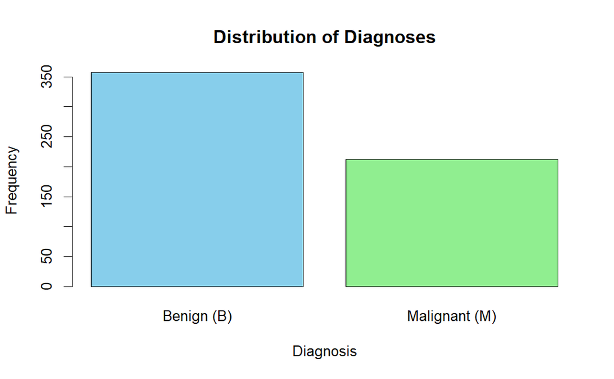

```r
# Creating a bar chart for the "diagnosis" column
barplot(table(bcp_dataset$diagnosis),
        main = "Distribution of Diagnoses",
        xlab = "Diagnosis",
        ylab = "Frequency",
        col = c("skyblue", "lightgreen"),
        names.arg = c("Benign (B)", "Malignant (M)"))
```

Based on the bar chart, which illustrates the distribution of diagnoses, it is evident that the dataset contains a higher frequency of Benign (B) diagnoses compared to Malignant (M) diagnoses. This observation suggests that Benign cases are more prevalent in the dataset compared to Malignant cases.

Since all the columns in the dataset are numeric, except for the first two columns, histograms present an ideal visualization method to explore the distribution of these features.

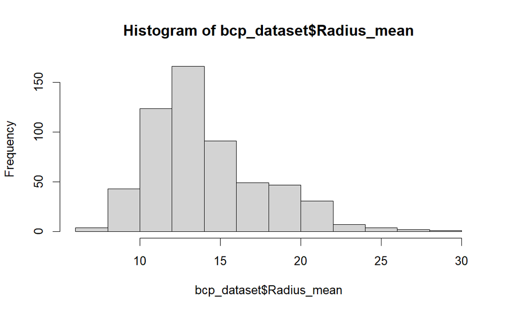

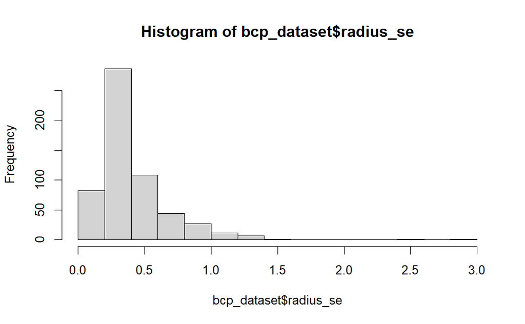

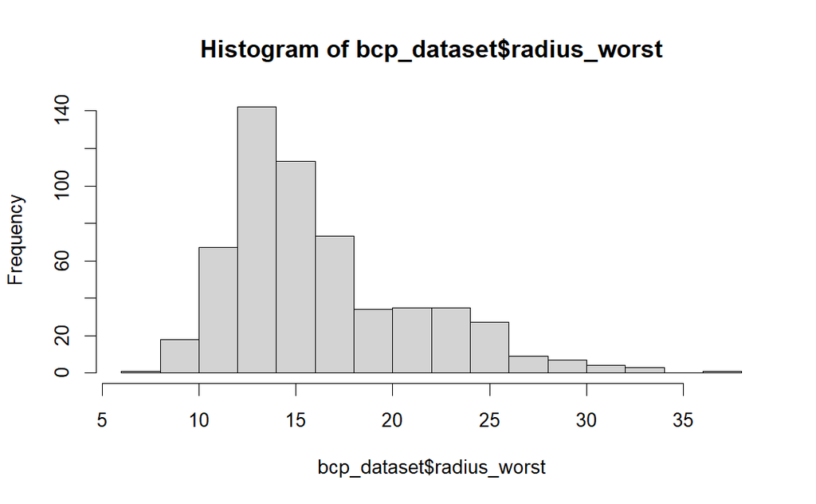

```r
# Create a histogram for the first column
hist(bcp_dataset$Radius_mean, col = "blue", main = "Histogram of Radius", xlab = "Value", ylab = "Frequency", xlim = range(c(bcp_dataset$Radius_mean, bcp_dataset$radius_se, bcp_dataset$radius_worst)), ylim = c(0, max(hist(bcp_dataset$Radius_mean)$counts, hist(bcp_dataset$radius_se)$counts, hist(bcp_dataset$radius_worst)$counts)))
```

```r
# Overlay histograms for the second and third columns
hist(bcp_dataset$radius_se, col = "red", add = TRUE)
hist(bcp_dataset$radius_worst, col = "green", add = TRUE)
```

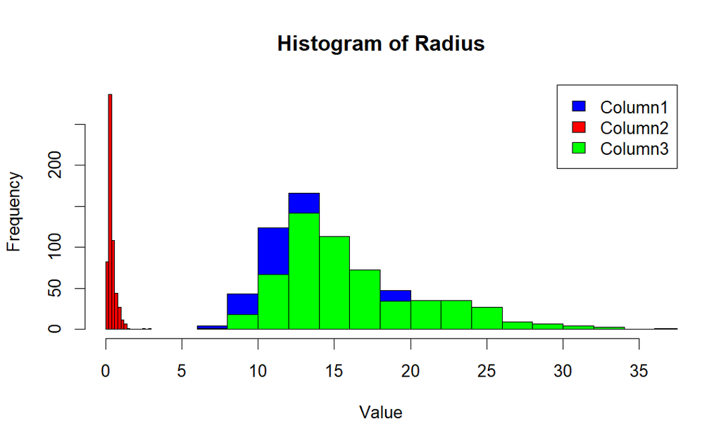

```r
# Add a legend
legend("topright", legend = c("Column1", "Column2", "Column3"), fill = c("blue", "red", "green"))
```

```r
NA
NA
NA
```

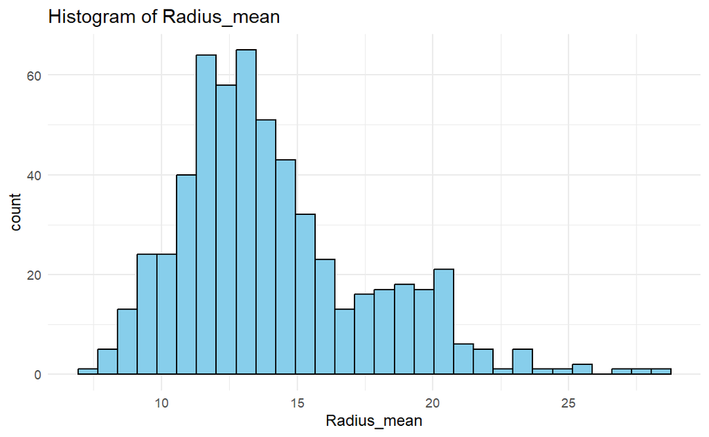

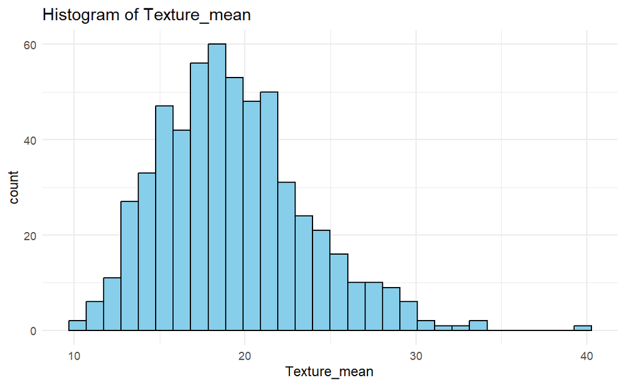

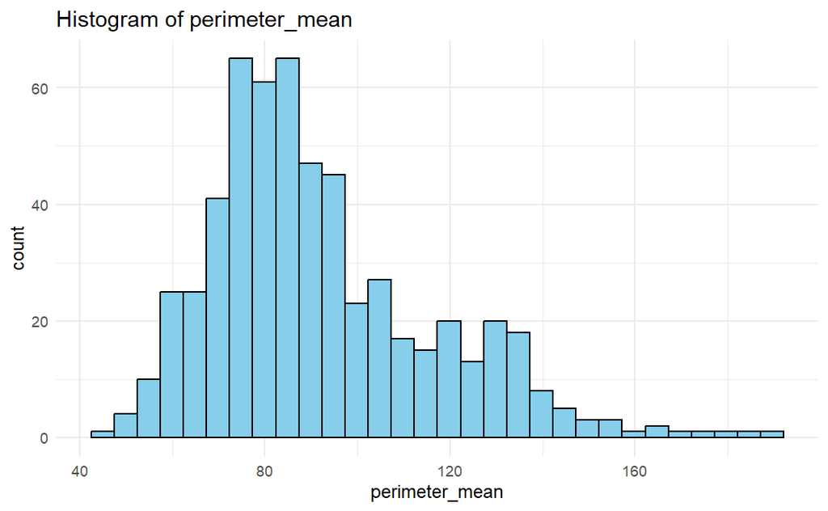

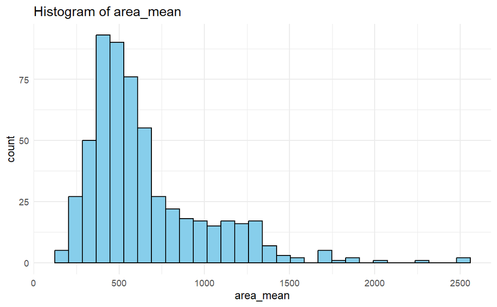

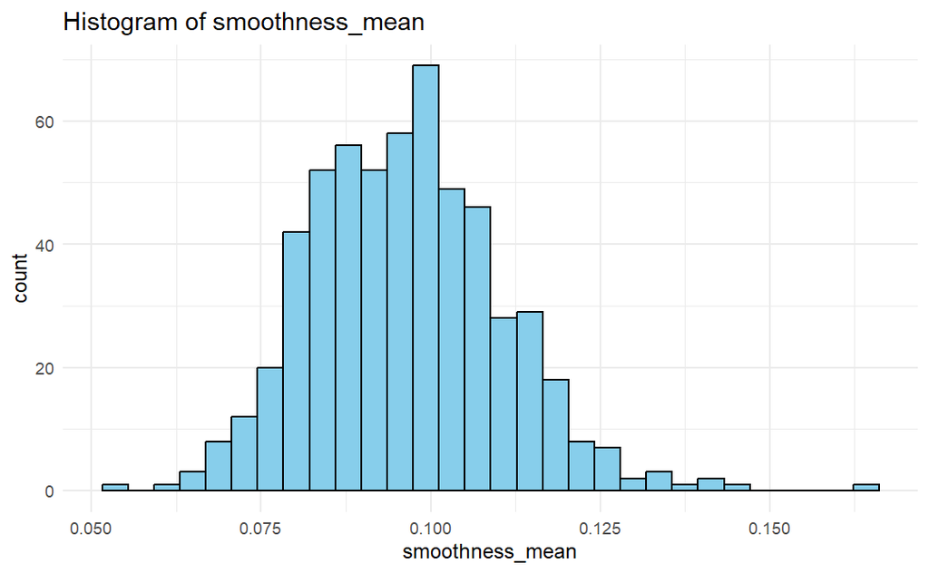

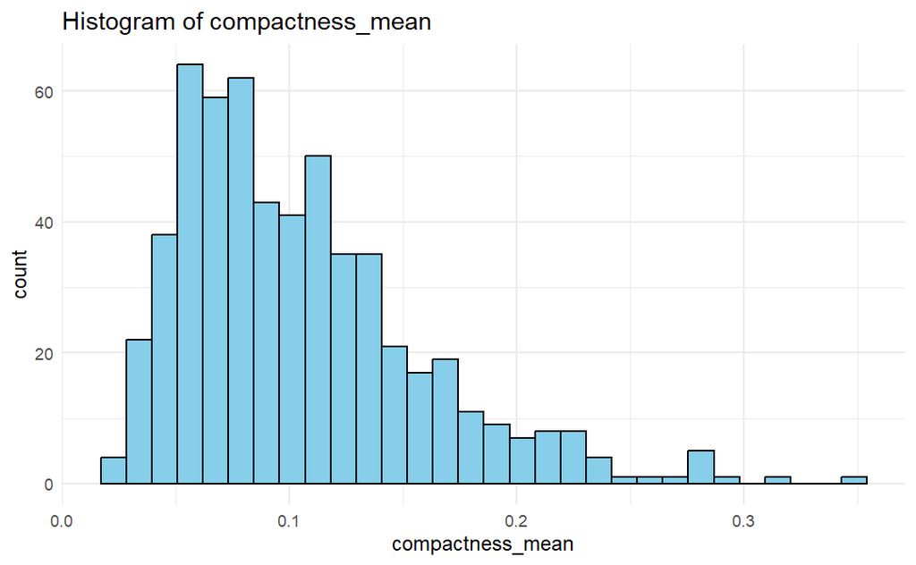

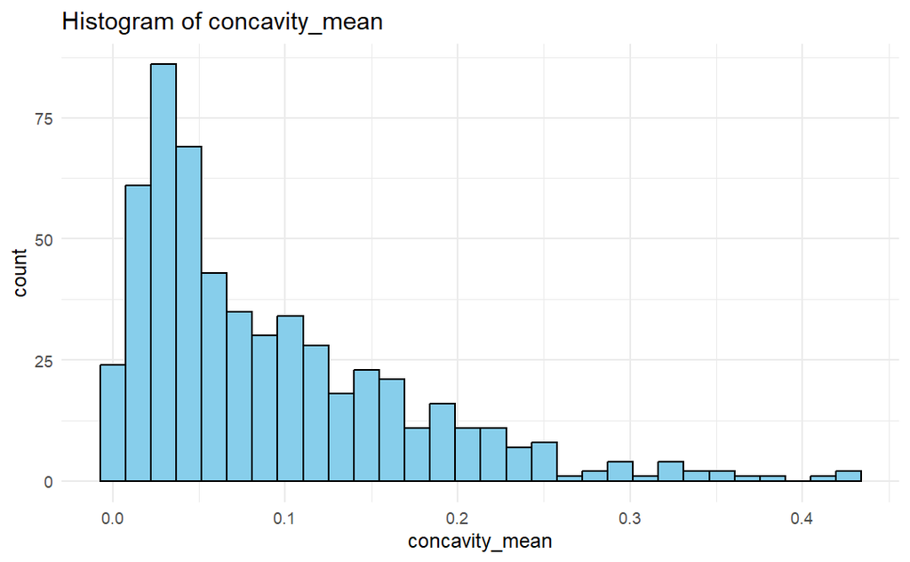

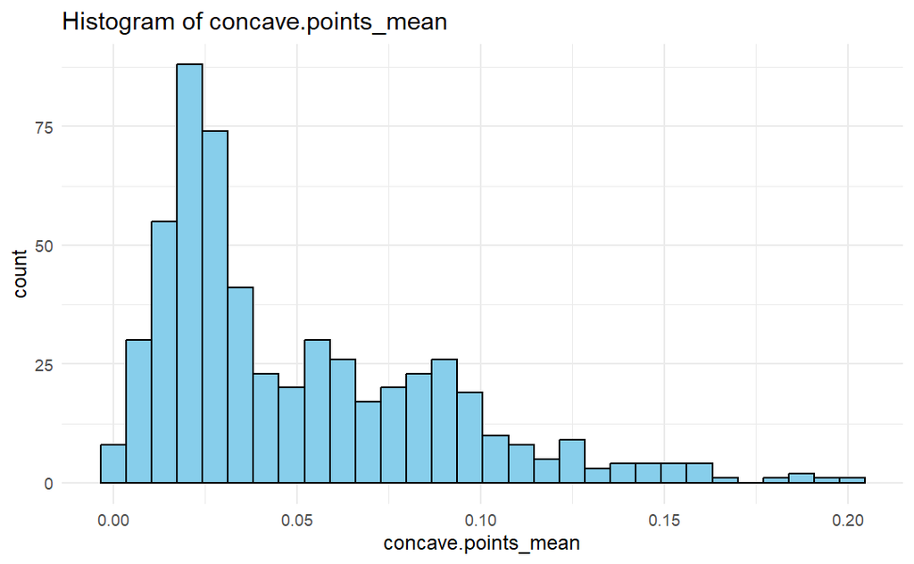

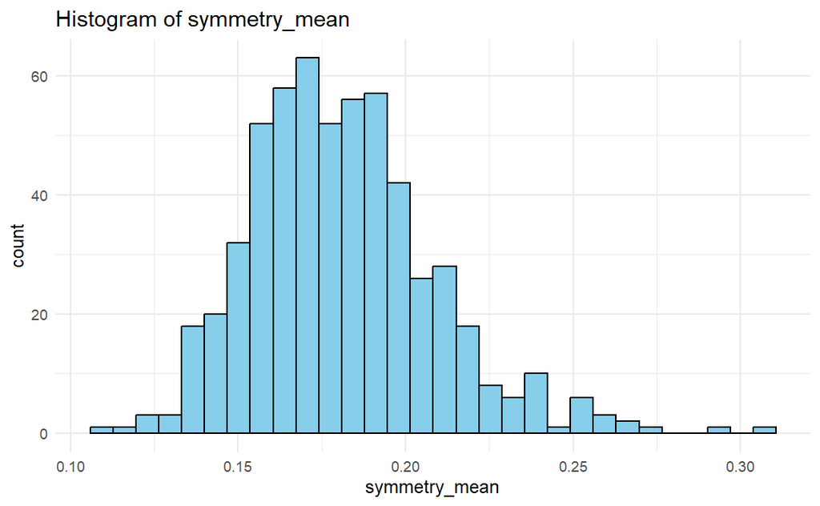

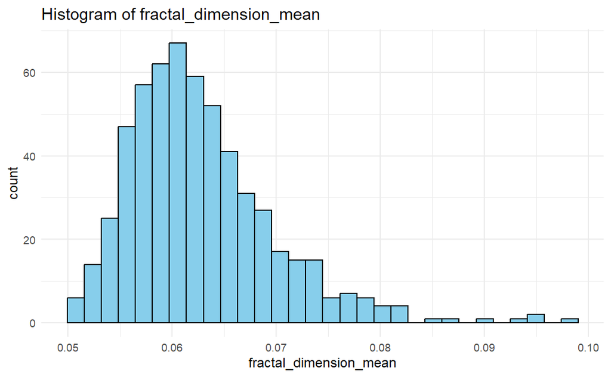

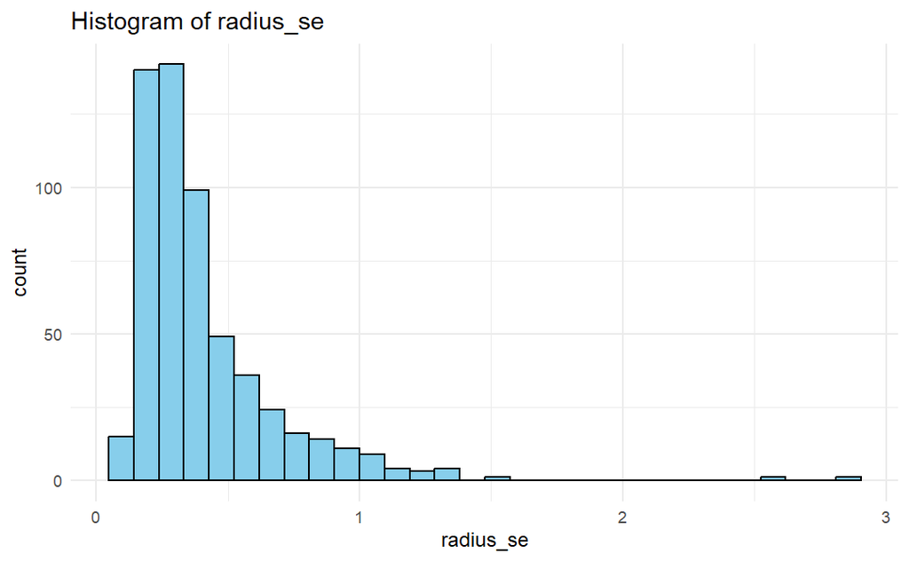

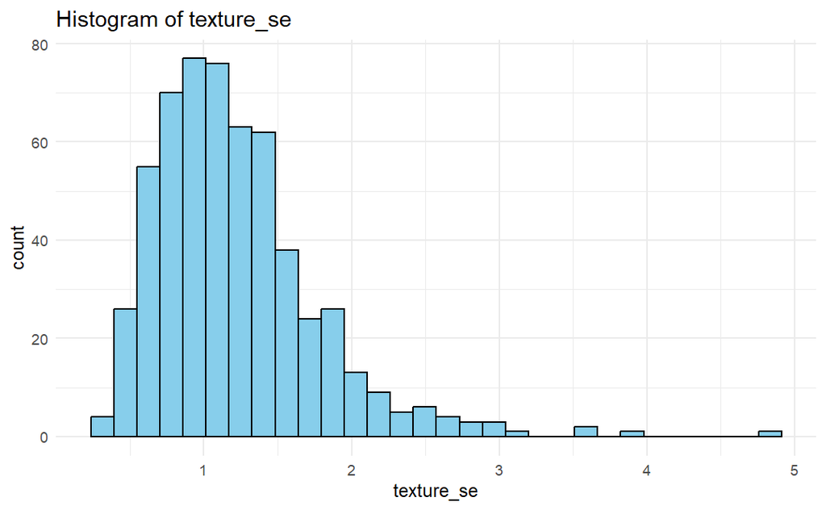

[18 more figures not shown]

```r
# Loading necessary libraries
library(ggplot2)
# Getting column names of numeric columns
numeric_columns <- names(bcp_dataset)[-(1:2)]

# Creating histograms for each numeric column
for (col in numeric_columns) {
  p <- ggplot(data = bcp_dataset, aes(x = !!as.name(col))) +
    geom_histogram(fill = "skyblue", color = "black") +
    labs(title = paste("Histogram of", col)) +
    theme_minimal()

  # Printing each histogram
  print(p)
}
```

```r
NA
NA
```

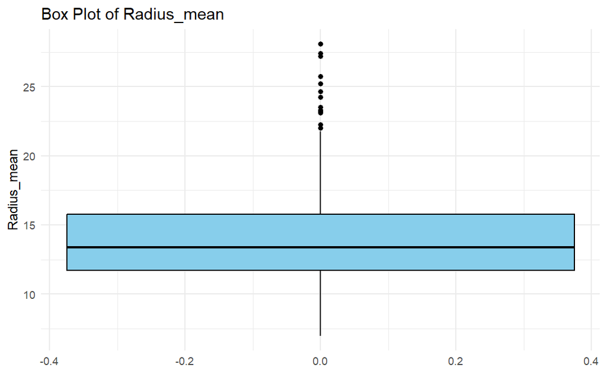

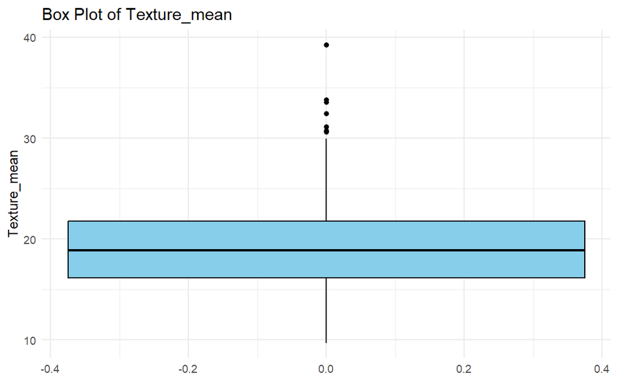

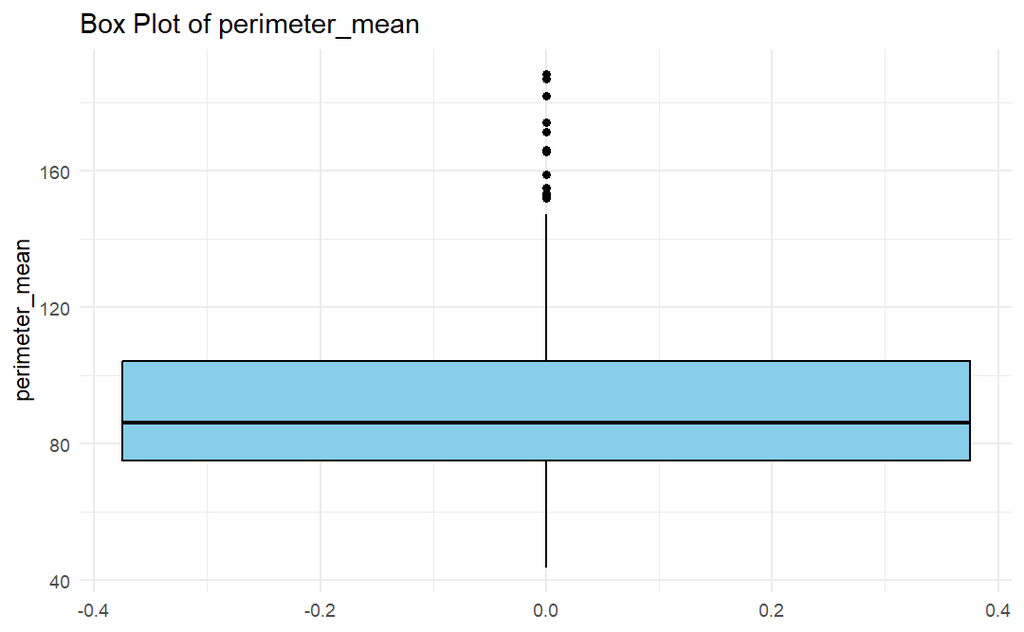

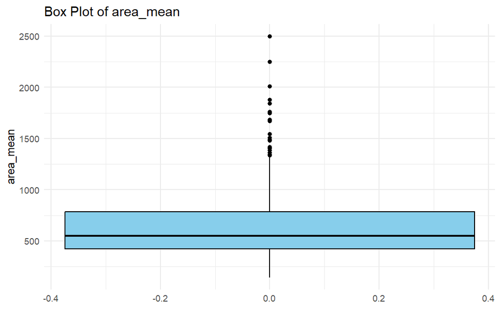

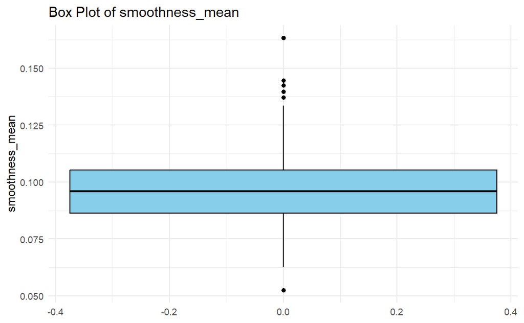

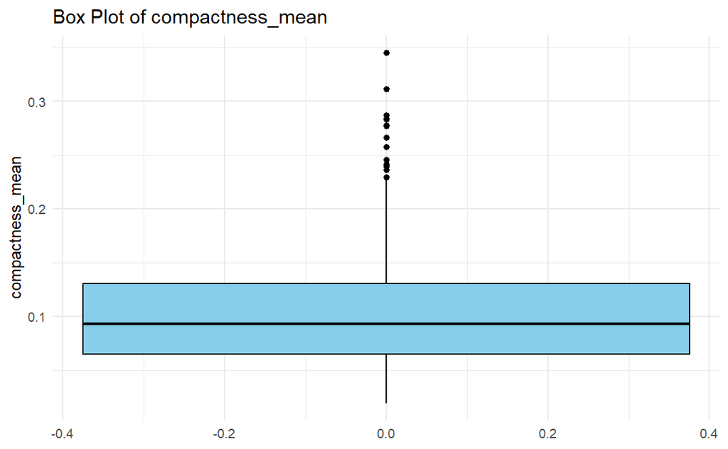

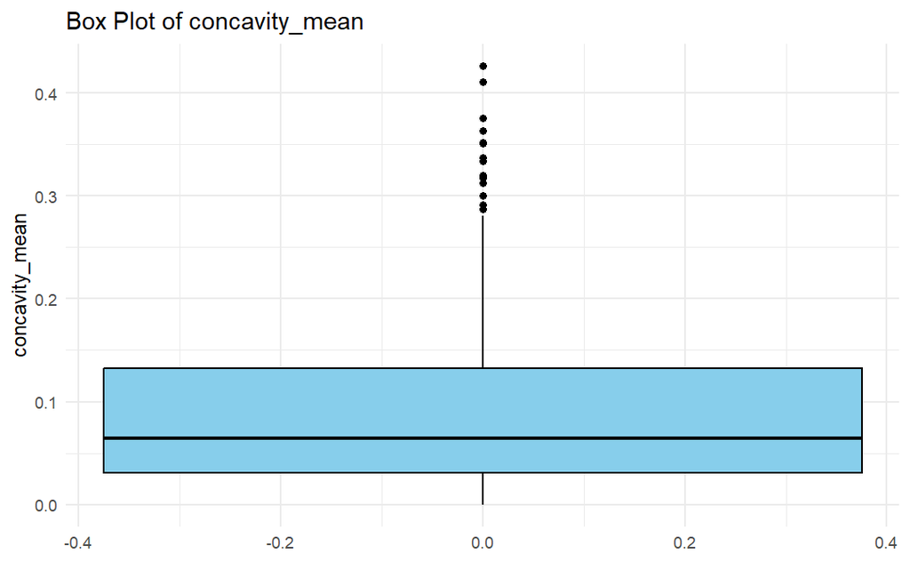

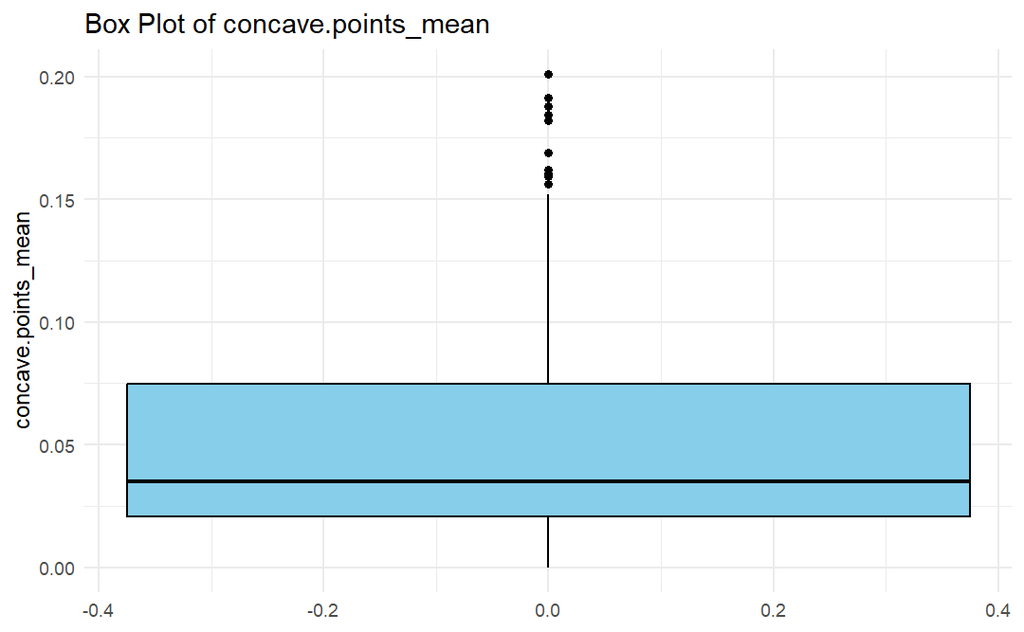

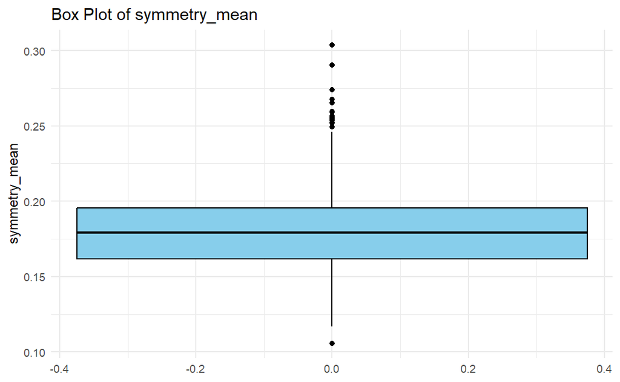

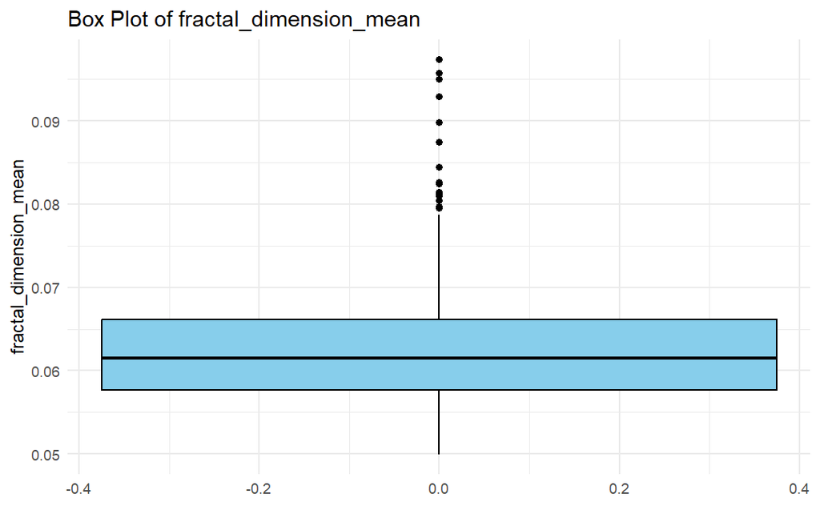

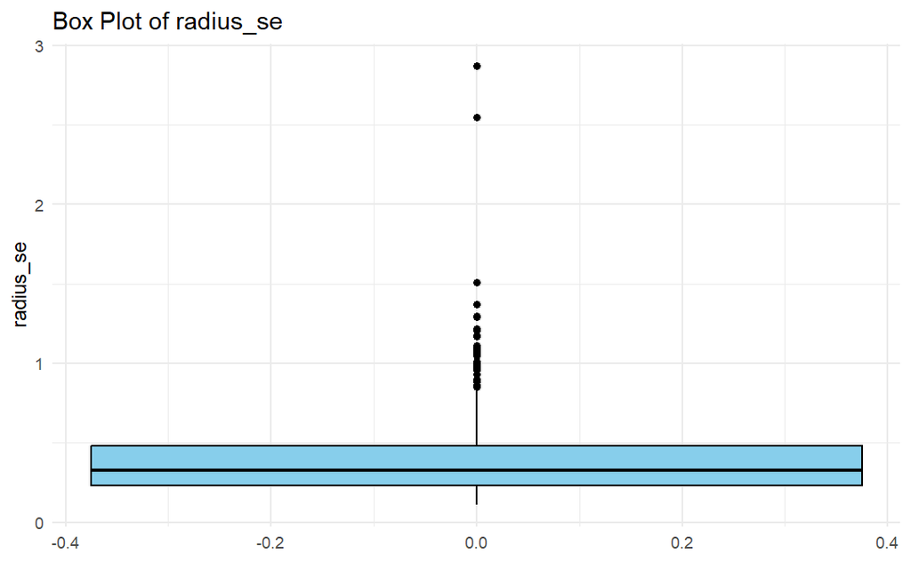

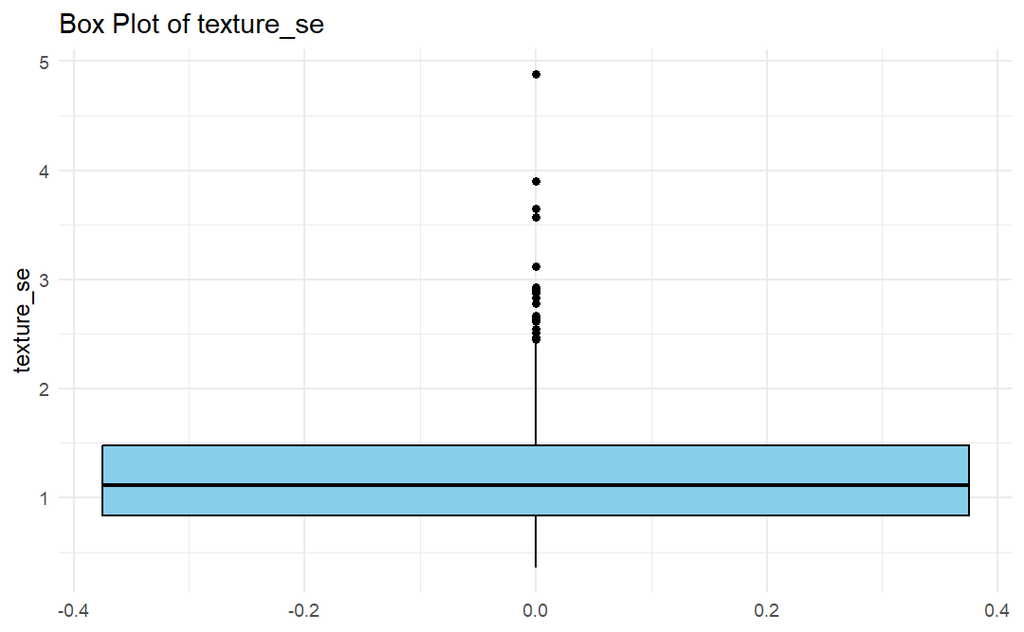

[18 more figures not shown]

```r
# Create box plots for each numeric column
for (col in numeric_columns) {
  # Create a box plot for the current column
  p <- ggplot(data = bcp_dataset, aes(y = !!as.name(col))) +
    geom_boxplot(fill = "skyblue", color = "black") +
    labs(title = paste("Box Plot of", col)) +
    theme_minimal()

  # Print the box plot
  print(p)
}
```

#### b) Examining Data Quality

Ensuring data quality is very important. Jack E. Olson claims that inaccurate data incurs significant costs for organizations in rectification efforts, customer attrition, forgone opportunities, and erroneous decisions. Examining data quality involves assessing the completeness, consistency, and accuracy of the dataset to ensure its reliability for analysis. This process includes identifying and addressing various issues such as missing values, outliers, duplicates, and inconsistencies. By thoroughly examining data quality, the trustworthiness of analysis results can be enhanced and mitigate potential biases or errors that could impact the validity of findings.

- Identifying variables with missing values and assessing their proportion in the dataset.

```r
missing_values <- colSums(is.na(bcp_dataset[, 2: 32]))
missing_values
```

```
              diagnosis             Radius_mean            Texture_mean
                      0                       0                       0
         perimeter_mean               area_mean         smoothness_mean
                      0                       0                       0
       compactness_mean          concavity_mean     concave.points_mean
                      1                      12                      12
          symmetry_mean  fractal_dimension_mean               radius_se
                      0                       0                       0
             texture_se            perimeter_se                 area_se
                      0                       0                       0
          smoothness_se          compactness_se            concavity_se
                      0                       0                      12
      concave.points_se             symmetry_se    fractal_dimension_se
                     12                       0                       1
           radius_worst           texture_worst         perimeter_worst
                      0                       0                       0
             area_worst        smoothness_worst       compactness_worst
                      0                       0                       0
        concavity_worst    concave.points_worst          symmetry_worst
                      0                       0                       0
fractal_dimension_worst
                      0
```

```r
na_percentage <- missing_values / nrow(bcp_dataset) * 100
print(na_percentage)
```

```
              diagnosis             Radius_mean            Texture_mean
              0.0000000               0.0000000               0.0000000
         perimeter_mean               area_mean         smoothness_mean
              0.0000000               0.0000000               0.0000000
       compactness_mean          concavity_mean     concave.points_mean
              0.1757469               2.1089631               2.1089631
          symmetry_mean  fractal_dimension_mean               radius_se
              0.0000000               0.0000000               0.0000000
             texture_se            perimeter_se                 area_se
              0.0000000               0.0000000               0.0000000
          smoothness_se          compactness_se            concavity_se
              0.0000000               0.0000000               2.1089631
      concave.points_se             symmetry_se    fractal_dimension_se
              2.1089631               0.0000000               0.1757469
           radius_worst           texture_worst         perimeter_worst
              0.0000000               0.0000000               0.0000000
             area_worst        smoothness_worst       compactness_worst
              0.0000000               0.0000000               0.0000000
        concavity_worst    concave.points_worst          symmetry_worst
              0.0000000               0.0000000               0.0000000
fractal_dimension_worst
              0.0000000
```

```r
na_summary <- data.frame(Missing_Count = missing_values, Missing_Percentage = na_percentage)

na_summary
```

|  | Missing_Count | Missing_Percentage |
| --- | --- | --- |
| diagnosis | 0 | 0.0000000 |
| Radius_mean | 0 | 0.0000000 |
| Texture_mean | 0 | 0.0000000 |
| perimeter_mean | 0 | 0.0000000 |
| area_mean | 0 | 0.0000000 |
| smoothness_mean | 0 | 0.0000000 |
| compactness_mean | 1 | 0.1757469 |
| concavity_mean | 12 | 2.1089631 |
| concave.points_mean | 12 | 2.1089631 |
| symmetry_mean | 0 | 0.0000000 |

[output cut: 21 more lines]

The analysis reveals that the dataset contains a negligible amount of missing values, with the highest percentage of missing values in any particular column being just slightly above 2%. While addressing missing values is crucial for ensuring the integrity of the dataset, the observed percentage indicates that missing values are relatively minor and manageable.

In the subsequent stage of the analysis, appropriate methods will be employed to handle these missing values effectively.

```r
# Installing and loading the gplots package
#install.packages("gplots")
#library(gplots)

# Sample data
#hm_num_data <- matrix(bcp_dataset[, 3:32])


# Create heatmap with heatmap.2()
#heatmap.2(hm_num_data, Rowv = NA, Colv = NA, dendrogram = "none", scale = "none", col = cm.colors(256))
```

- Checking if there is any duplicate records in the dataset.

```r
# Checking for duplicate rows
duplicate_rows <- bcp_dataset[duplicated(bcp_dataset), ]

# Printing duplicate rows, if any
if (nrow(duplicate_rows) > 0) {
  print("Duplicate rows found:")
  print(duplicate_rows)
} else {
  print("No duplicate rows found.")
}
```

```
[1] "No duplicate rows found."
```

According to this output, there is no duplicated records in the dataset.

## 2.3 Data Preparation

Data preparation encompasses the process of transforming raw data into a clean, structured format suitable for analysis or modeling tasks. It is essential for ensuring data quality, consistency, and reliability, ultimately enabling accurate and meaningful insights to be derived from the data. The importance of data preparation lies in its role in addressing various data challenges, such as missing values, outliers, and inconsistencies, which can adversely affect analysis outcomes if left unattended. The steps involved in data preparation typically include data cleaning, transformation, integration, formatting, splitting, and documentation. These steps aim to remove noise, standardize data formats, enhance data quality, and prepare the dataset for further analysis or modeling. By systematically preparing the data, analysts can mitigate potential biases, improve the robustness of analysis results, and make informed decisions based on trustworthy data.

### 2.3.1 Handling Missing Values

Handling missing values involves identifying and addressing instances where data values are not present in the dataset. Techniques such as imputation with estimated values, deletion of entire rows with missing values, or substitution with measures like the median or mode are can be used to handle those missing values. For the breast cancer prediction dataset, the missing values will be imputed with the mean.

- Before handling the missing values, it is important to convert the categorical columns into a logical column.

In the breast cancer prediction dataset, there is a column called diagnosis which contains two categorical values. These values are M (Malignant) or B (Benign). So, these values will be replaced by 1 and 0.

```r
# Replace 'M' with 1 and 'B' with 0 in the 'diagnosis' column
modified_bcp_dataset <- bcp_dataset
modified_bcp_dataset$diagnosis <- ifelse(bcp_dataset$diagnosis == "M", 1, 0)
head(modified_bcp_dataset, 10)
```

|  | id | diagnosis | Radius_mean | Texture_mean | perimeter_mean | area_mean | smoothness_mean | compactness_mean | concavity_mean | concave.points_mean | symmetry_mean | fractal_dimension_mean | radius_se | texture_se | perimeter_se | area_se | smoothness_se | compactness_se | concavity_se | concave.points_se | symmetry_se | fractal_dimension_se | radius_worst | texture_worst | perimeter_worst | area_worst | smoothness_worst | compactness_worst | concavity_worst | … |
| --- | --- | --- | --- | --- | --- | --- | --- | --- | --- | --- | --- | --- | --- | --- | --- | --- | --- | --- | --- | --- | --- | --- | --- | --- | --- | --- | --- | --- | --- | --- |
| 1 | 842302 | 1 | 17.99 | 10.38 | 122.80 | 1001.0 | 0.11840 | 0.27760 | 0.30010 | 0.14710 | 0.2419 | 0.07871 | 1.0950 | 0.9053 | 8.589 | 153.40 | 0.006399 | 0.04904 | 0.05373 | 0.01587 | 0.03003 | 0.006193 | 25.38 | 17.33 | 184.60 | 2019.0 | 0.1622 | 0.6656 | 0.7119 | … |
| 2 | 842517 | 1 | 20.57 | 21.77 | 132.90 | 1326.0 | 0.08474 | 0.07864 | 0.08690 | 0.07017 | 0.1812 | 0.05667 | 0.5435 | 0.7339 | 3.398 | 74.08 | 0.005225 | 0.01308 | 0.01860 | 0.01340 | 0.01389 | 0.003532 | 24.99 | 23.41 | 158.80 | 1956.0 | 0.1238 | 0.1866 | 0.2416 | … |
| 3 | 84300903 | 1 | 19.69 | 21.25 | 130.00 | 1203.0 | 0.10960 | 0.15990 | 0.19740 | 0.12790 | 0.2069 | 0.05999 | 0.7456 | 0.7869 | 4.585 | 94.03 | 0.006150 | 0.04006 | 0.03832 | 0.02058 | 0.02250 | 0.004571 | 23.57 | 25.53 | 152.50 | 1709.0 | 0.1444 | 0.4245 | 0.4504 | … |
| 4 | 84348301 | 1 | 11.42 | 20.38 | 77.58 | 386.1 | 0.14250 | 0.28390 | 0.24140 | 0.10520 | 0.2597 | 0.09744 | 0.4956 | 1.1560 | 3.445 | 27.23 | 0.009110 | 0.07458 | 0.05661 | 0.01867 | 0.05963 | 0.009208 | 14.91 | 26.50 | 98.87 | 567.7 | 0.2098 | 0.8663 | 0.6869 | … |
| 5 | 84358402 | 1 | 20.29 | 14.34 | 135.10 | 1297.0 | 0.10030 | 0.13280 | 0.19800 | 0.10430 | 0.1809 | 0.05883 | 0.7572 | 0.7813 | 5.438 | 94.44 | 0.011490 | 0.02461 | 0.05688 | 0.01885 | 0.01756 | 0.005115 | 22.54 | 16.67 | 152.20 | 1575.0 | 0.1374 | 0.2050 | 0.4000 | … |
| 6 | 843786 | 1 | 12.45 | 15.70 | 82.57 | 477.1 | 0.12780 | 0.17000 | 0.15780 | 0.08089 | 0.2087 | 0.07613 | 0.3345 | 0.8902 | 2.217 | 27.19 | 0.007510 | 0.03345 | 0.03672 | 0.01137 | 0.02165 | 0.005082 | 15.47 | 23.75 | 103.40 | 741.6 | 0.1791 | 0.5249 | 0.5355 | … |
| 7 | 844359 | 1 | 18.25 | 19.98 | 119.60 | 1040.0 | 0.09463 | 0.10900 | 0.11270 | 0.07400 | 0.1794 | 0.05742 | 0.4467 | 0.7732 | 3.180 | 53.91 | 0.004314 | 0.01382 | 0.02254 | 0.01039 | 0.01369 | 0.002179 | 22.88 | 27.66 | 153.20 | 1606.0 | 0.1442 | 0.2576 | 0.3784 | … |
| 8 | 84458202 | 1 | 13.71 | 20.83 | 90.20 | 577.9 | 0.11890 | 0.16450 | 0.09366 | 0.05985 | 0.2196 | 0.07451 | 0.5835 | 1.3770 | 3.856 | 50.96 | 0.008805 | 0.03029 | 0.02488 | 0.01448 | 0.01486 | 0.005412 | 17.06 | 28.14 | 110.60 | 897.0 | 0.1654 | 0.3682 | 0.2678 | … |
| 9 | 844981 | 1 | 13.00 | 21.82 | 87.50 | 519.8 | 0.12730 | 0.19320 | 0.18590 | 0.09353 | 0.2350 | 0.07389 | 0.3063 | 1.0020 | 2.406 | 24.32 | 0.005731 | 0.03502 | 0.03553 | 0.01226 | 0.02143 | 0.003749 | 15.49 | 30.73 | 106.20 | 739.3 | 0.1703 | 0.5401 | 0.5390 | … |
| 10 | 84501001 | 1 | 12.46 | 24.04 | 83.97 | 475.9 | 0.11860 | 0.23960 | 0.22730 | 0.08543 | 0.2030 | 0.08243 | 0.2976 | 1.5990 | 2.039 | 23.94 | 0.007149 | 0.07217 | 0.07743 | 0.01432 | 0.01789 | 0.010080 | 15.09 | 40.68 | 97.65 | 711.4 | 0.1853 | 1.0580 | 1.1050 | … |

```r
tail(modified_bcp_dataset, 10)
```

|  | id | diagnosis | Radius_mean | Texture_mean | perimeter_mean | area_mean | smoothness_mean | compactness_mean | concavity_mean | concave.points_mean | symmetry_mean | fractal_dimension_mean | radius_se | texture_se | perimeter_se | area_se | smoothness_se | compactness_se | concavity_se | concave.points_se | symmetry_se | fractal_dimension_se | radius_worst | texture_worst | perimeter_worst | area_worst | smoothness_worst | compactness_worst | concavity_worst | … |
| --- | --- | --- | --- | --- | --- | --- | --- | --- | --- | --- | --- | --- | --- | --- | --- | --- | --- | --- | --- | --- | --- | --- | --- | --- | --- | --- | --- | --- | --- | --- |
| 560 | 925291 | 0 | 11.51 | 23.93 | 74.52 | 403.5 | 0.09261 | 0.10210 | 0.11120 | 0.04105 | 0.1388 | 0.06570 | 0.2388 | 2.904 | 1.936 | 16.97 | 0.008200 | 0.029820 | 0.05738 | 0.01267 | 0.01488 | 0.004738 | 12.480 | 37.16 | 82.28 | 474.2 | 0.12980 | 0.25170 | 0.3630 | … |
| 561 | 925292 | 0 | 14.05 | 27.15 | 91.38 | 600.4 | 0.09929 | 0.11260 | 0.04462 | 0.04304 | 0.1537 | 0.06171 | 0.3645 | 1.492 | 2.888 | 29.84 | 0.007256 | 0.026780 | 0.02071 | 0.01626 | 0.02080 | 0.005304 | 15.300 | 33.17 | 100.20 | 706.7 | 0.12410 | 0.22640 | 0.1326 | … |
| 562 | 925311 | 0 | 11.20 | 29.37 | 70.67 | 386.0 | 0.07449 | 0.03558 | NA | NA | 0.1060 | 0.05502 | 0.3141 | 3.896 | 2.041 | 22.81 | 0.007594 | 0.008878 | NA | NA | 0.01989 | 0.001773 | 11.920 | 38.30 | 75.19 | 439.6 | 0.09267 | 0.05494 | 0.0000 | … |
| 563 | 925622 | 1 | 15.22 | 30.62 | 103.40 | 716.9 | 0.10480 | 0.20870 | 0.25500 | 0.09429 | 0.2128 | 0.07152 | 0.2602 | 1.205 | 2.362 | 22.65 | 0.004625 | 0.048440 | 0.07359 | 0.01608 | 0.02137 | 0.006142 | 17.520 | 42.79 | 128.70 | 915.0 | 0.14170 | 0.79170 | 1.1700 | … |
| 564 | 926125 | 1 | 20.92 | 25.09 | 143.00 | 1347.0 | 0.10990 | 0.22360 | 0.31740 | 0.14740 | 0.2149 | 0.06879 | 0.9622 | 1.026 | 8.758 | 118.80 | 0.006399 | 0.043100 | 0.07845 | 0.02624 | 0.02057 | 0.006213 | 24.290 | 29.41 | 179.10 | 1819.0 | 0.14070 | 0.41860 | 0.6599 | … |
| 565 | 926424 | 1 | 21.56 | 22.39 | 142.00 | 1479.0 | 0.11100 | 0.11590 | 0.24390 | 0.13890 | 0.1726 | 0.05623 | 1.1760 | 1.256 | 7.673 | 158.70 | 0.010300 | 0.028910 | 0.05198 | 0.02454 | 0.01114 | NA | 25.450 | 26.40 | 166.10 | 2027.0 | 0.14100 | 0.21130 | 0.4107 | … |
| 566 | 926682 | 1 | 20.13 | 28.25 | 131.20 | 1261.0 | 0.09780 | 0.10340 | 0.14400 | 0.09791 | 0.1752 | 0.05533 | 0.7655 | 2.463 | 5.203 | 99.04 | 0.005769 | 0.024230 | 0.03950 | 0.01678 | 0.01898 | 0.002498 | 23.690 | 38.25 | 155.00 | 1731.0 | 0.11660 | 0.19220 | 0.3215 | … |
| 567 | 926954 | 1 | 16.60 | 28.08 | 108.30 | 858.1 | 0.08455 | 0.10230 | 0.09251 | 0.05302 | 0.1590 | 0.05648 | 0.4564 | 1.075 | 3.425 | 48.55 | 0.005903 | 0.037310 | 0.04730 | 0.01557 | 0.01318 | 0.003892 | 18.980 | 34.12 | 126.70 | 1124.0 | 0.11390 | 0.30940 | 0.3403 | … |
| 568 | 927241 | 1 | 20.60 | 29.33 | 140.10 | 1265.0 | 0.11780 | 0.27700 | 0.35140 | 0.15200 | 0.2397 | 0.07016 | 0.7260 | 1.595 | 5.772 | 86.22 | 0.006522 | 0.061580 | 0.07117 | 0.01664 | 0.02324 | 0.006185 | 25.740 | 39.42 | 184.60 | 1821.0 | 0.16500 | 0.86810 | 0.9387 | … |
| 569 | 92751 | 0 | 7.76 | 24.54 | 47.92 | 181.0 | 0.05263 | 0.04362 | NA | NA | 0.1587 | 0.05884 | 0.3857 | 1.428 | 2.548 | 19.15 | 0.007189 | 0.004660 | NA | NA | 0.02676 | 0.002783 | 9.456 | 30.37 | 59.16 | 268.6 | 0.08996 | 0.06444 | 0.0000 | … |

```r
NA
```

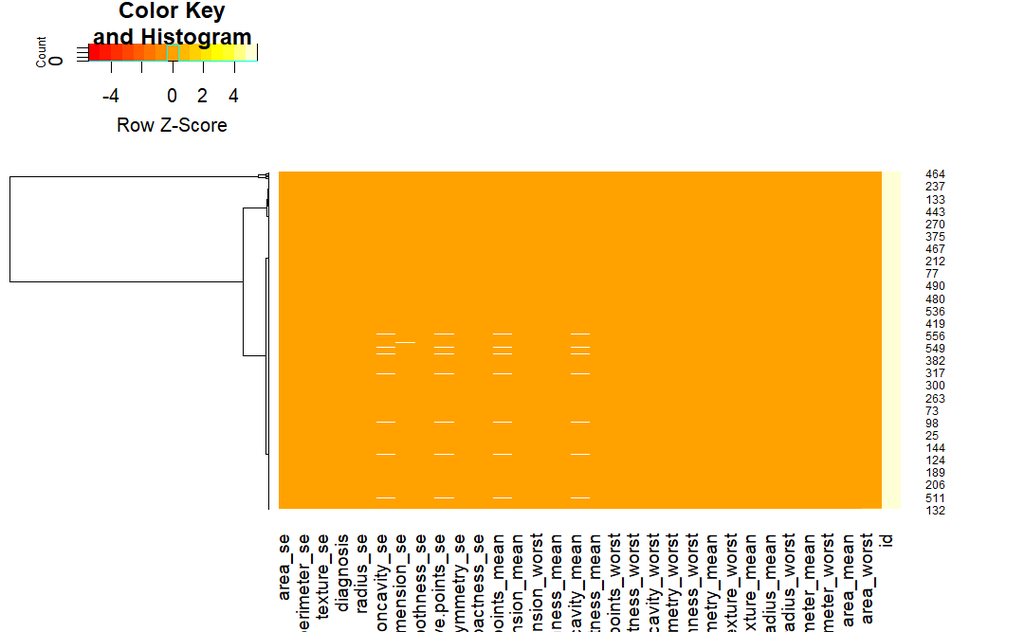

```r
#install.packages("gplots")
library(gplots)
ad_matrix <- as.matrix(modified_bcp_dataset)
heatmap.2(ad_matrix, dendrogram="row", scale="row", trace="none", key=TRUE)
```

In the heatmap diagram above, the white stripes indicate that there are some missing values in the dataset.

```r
#After handling the missing values, the dataset will be stored in a new variable called "imputed_bcp_dataset".


# Imputing missing values with mean
imputed_bcp_dataset <- apply(modified_bcp_dataset, 2, function(x) ifelse(is.na(x), mean(x, na.rm = TRUE), x))
```

- Now, checking again if there is any missing values in the dataset.

```r
missing_value_sums <- colSums(is.na(imputed_bcp_dataset))
missing_value_sums
```

```
                     id               diagnosis             Radius_mean
                      0                       0                       0
           Texture_mean          perimeter_mean               area_mean
                      0                       0                       0
        smoothness_mean        compactness_mean          concavity_mean
                      0                       0                       0
    concave.points_mean           symmetry_mean  fractal_dimension_mean
                      0                       0                       0
              radius_se              texture_se            perimeter_se
                      0                       0                       0
                area_se           smoothness_se          compactness_se
                      0                       0                       0
           concavity_se       concave.points_se             symmetry_se
                      0                       0                       0
   fractal_dimension_se            radius_worst           texture_worst
                      0                       0                       0
        perimeter_worst              area_worst        smoothness_worst
                      0                       0                       0
      compactness_worst         concavity_worst    concave.points_worst
                      0                       0                       0
         symmetry_worst fractal_dimension_worst
                      0                       0
```

It clearly shows there is no more missing values in the dataset. This also reflects in the heatmap diagram bellow.

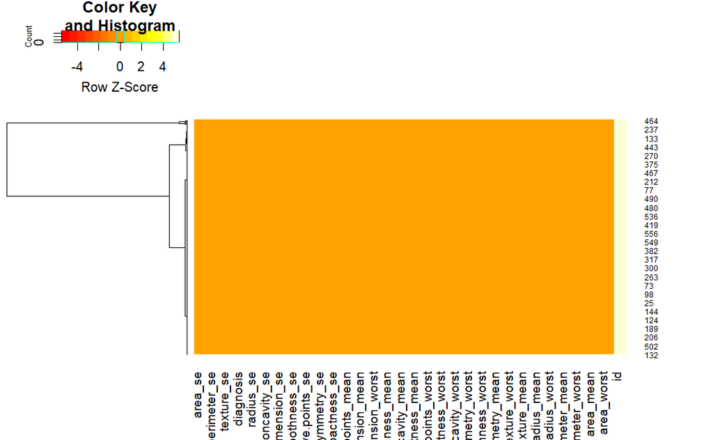

```r
#install.packages("gplots")
library(gplots)
ad_matrix <- as.matrix(imputed_bcp_dataset)
heatmap.2(ad_matrix, dendrogram="row", scale="row", trace="none", key=TRUE)
```

### 2.3.2 Features and Target Selection

In the Features and Target Selection stage, the relevant features (independent variables) and the target variable (dependent variable) are identified and selected from the dataset. Features represent the variables used to predict or explain the target variable, while the target variable is the variable of interest that the model aims to predict or understand. This stage involves analyzing the dataset to determine which features are likely to have predictive power or explanatory value for the target variable. The selected features are then separated from the target variable to form the input data for subsequent modeling or analysis tasks. This process is crucial for defining the scope of the analysis and ensuring that the model focuses on the most relevant information for achieving the desired outcomes.

The dataset contains a variables called “id” which may not have an considerable impact on the prediction of diagnosis. Therefore, that varable will not be passed to the algorithm and dropped in this stage.

- Dimension before dropping id column:

```r
paste(dim(imputed_bcp_dataset))
```

```
[1] "569" "32"
```

```r
# Storing the dataset in a new variable with the dropped column
new_bcp_dataset <- imputed_bcp_dataset[ , 2:ncol(imputed_bcp_dataset)]
```

- Dimension after dropping id column:

```r
paste(dim(new_bcp_dataset))
```

```
[1] "569" "31"
```

In the dataset, the ‘diagnosis’ column represents the target variable, while the remaining columns are features. However, it may be needed to omit some features based on their correlation with each other.

- It is important to check the correlation among the features before selecting the features. The following code shows the correlation matrix.

```r
# Calculate the correlation matrix
correlation_matrix <- cor(new_bcp_dataset[ , -1])

# Print the correlation matrix
print(correlation_matrix)
```

```
                         Radius_mean Texture_mean perimeter_mean    area_mean
Radius_mean              1.000000000  0.326715992    0.997855281  0.987357170
Texture_mean             0.326715992  1.000000000    0.332230809  0.324149315
perimeter_mean           0.997855281  0.332230809    1.000000000  0.986506804
area_mean                0.987357170  0.324149315    0.986506804  1.000000000
smoothness_mean          0.170581187 -0.024736854    0.207278164  0.177028377
compactness_mean         0.507026169  0.237121469    0.557741510  0.499236085
concavity_mean           0.651750720  0.309221084    0.691467883  0.668069563
concave.points_mean      0.798082796  0.302631665    0.826812965  0.806759617
symmetry_mean            0.147741242  0.071390300    0.183027212  0.151293079
fractal_dimension_mean  -0.311630826 -0.077844082   -0.261476908 -0.283109812
radius_se                0.679090388  0.276635195    0.691765014  0.732562227
texture_se              -0.097317443  0.384854322   -0.086761078 -0.066280214
perimeter_se             0.674171616  0.282052696    0.693134890  0.726628328
area_se                  0.735863663  0.261012106    0.744982694  0.800085921
smoothness_se           -0.222600125  0.005622464   -0.202694026 -0.166776667
compactness_se           0.205999980  0.190806421    0.250743681  0.212582551
concavity_se             0.164133880  0.146915189    0.198245508  0.184361029
concave.points_se        0.331503994  0.176014875    0.363513683  0.339796472
symmetry_se             -0.104320881  0.007808115   -0.081629327 -0.072496588
fractal_dimension_se    -0.043266648  0.054073484   -0.006132999 -0.020580645
radius_worst             0.969538973  0.355462744    0.969476363  0.962746086
texture_worst            0.297007644  0.911275206    0.303038372  0.287488627
perimeter_worst          0.965136514  0.360485456    0.970386887  0.959119574
area_worst               0.941082460  0.346575691    0.941549808  0.959213326
smoothness_worst         0.119616140  0.076874942    0.150549404  0.123522939
compactness_worst        0.413462823  0.277075138    0.455774228  0.390410309
concavity_worst          0.526911462  0.300730572    0.563879263  0.512605920
concave.points_worst     0.744214198  0.297040289    0.771240789  0.722016626
symmetry_worst           0.163953335  0.104589947    0.189115040  0.143569914
fractal_dimension_worst  0.007065886  0.119643634    0.051018530  0.003737597
                        smoothness_mean compactness_mean concavity_mean
Radius_mean                  0.17058119       0.50702617      0.6517507
Texture_mean                -0.02473685       0.23712147      0.3092211
perimeter_mean               0.20727816       0.55774151      0.6914679
area_mean                    0.17702838       0.49923609      0.6680696
smoothness_mean              1.00000000       0.65813980      0.5113443
compactness_mean             0.65813980       1.00000000      0.8687590
concavity_mean               0.51134430       0.86875899      1.0000000
concave.points_mean          0.54325064       0.81615885      0.9191615
```

[output cut: 286 more lines]

```
compactness_se                      0.590972763
concavity_se                        0.434913643
concave.points_se                   0.305420313
symmetry_se                         0.078079476
fractal_dimension_se                0.591552466
radius_worst                        0.093491979
texture_worst                       0.219122425
perimeter_worst                     0.138956862
area_worst                          0.079647034
smoothness_worst                    0.617624192
compactness_worst                   0.810454856
concavity_worst                     0.686510921
concave.points_worst                0.511114146
symmetry_worst                      0.537848206
fractal_dimension_worst             1.000000000
```

```r
#install.packages("caret")

# Loading necessary library
library(caret)
suppressWarnings(library(caret))
suppressWarnings(library(ggplot2))


# Finding columns with correlations over 0.8
highly_correlated_cols <- findCorrelation(correlation_matrix, cutoff = 0.8)

# Obtaining names of columns to drop
cols_to_drop <- colnames(correlation_matrix)[highly_correlated_cols]

# The breast cancer dataset after dropping the highly correlated dataset.
processed_bcp_dataset <- new_bcp_dataset[, !colnames(new_bcp_dataset) %in% cols_to_drop]

head(processed_bcp_dataset, 3)
```

```
     diagnosis area_mean symmetry_mean fractal_dimension_mean radius_se
[1,]         1      1001        0.2419                0.07871    1.0950
[2,]         1      1326        0.1812                0.05667    0.5435
[3,]         1      1203        0.2069                0.05999    0.7456
     texture_se smoothness_se concavity_se concave.points_se symmetry_se
[1,]     0.9053      0.006399      0.05373           0.01587     0.03003
[2,]     0.7339      0.005225      0.01860           0.01340     0.01389
[3,]     0.7869      0.006150      0.03832           0.02058     0.02250
     fractal_dimension_se texture_worst smoothness_worst symmetry_worst
[1,]             0.006193         17.33           0.1622         0.4601
[2,]             0.003532         23.41           0.1238         0.2750
[3,]             0.004571         25.53           0.1444         0.3613
     fractal_dimension_worst
[1,]                 0.11890
[2,]                 0.08902
[3,]                 0.08758
```

- The dimension of the processed dataset after dropping the highly correlated columns.

```r
print(dim(processed_bcp_dataset))
```

```
[1] 569  15
```

```r
# Calculate the correlation matrix
new_correlation_matrix <- cor(processed_bcp_dataset[ , -1])

# Print the correlation matrix
print(new_correlation_matrix)
```

```
                           area_mean symmetry_mean fractal_dimension_mean
area_mean                1.000000000    0.15129308          -0.2831098117
symmetry_mean            0.151293079    1.00000000           0.4799213301
fractal_dimension_mean  -0.283109812    0.47992133           1.0000000000
radius_se                0.732562227    0.30337926           0.0001109951
texture_se              -0.066280214    0.12805293           0.1641739659
smoothness_se           -0.166776667    0.18732117           0.4019644254
concavity_se             0.184361029    0.34307371           0.4607295712
concave.points_se        0.339796472    0.40279480           0.3715606896
symmetry_se             -0.072496588    0.44913654           0.3450073971
fractal_dimension_se    -0.020580645    0.33188683           0.6884240189
texture_worst            0.287488627    0.09065069          -0.0512692020
smoothness_worst         0.123522939    0.42667503           0.5049420754
symmetry_worst           0.143569914    0.69982580           0.3340186839
fractal_dimension_worst  0.003737597    0.43841350           0.7672967792
                           radius_se  texture_se smoothness_se concavity_se
area_mean               0.7325622270 -0.06628021   -0.16677667    0.1843610
symmetry_mean           0.3033792632  0.12805293    0.18732117    0.3430737
fractal_dimension_mean  0.0001109951  0.16417397    0.40196443    0.4607296
radius_se               1.0000000000  0.21324734    0.16451422    0.3312400
texture_se              0.2132473373  1.00000000    0.39724285    0.2353007
smoothness_se           0.1645142198  0.39724285    1.00000000    0.2953764
concavity_se            0.3312399703  0.23530071    0.29537637    1.0000000
concave.points_se       0.5251992089  0.31054566    0.38577510    0.7680582
symmetry_se             0.2405673625  0.41162068    0.41350613    0.3402786
fractal_dimension_se    0.2269363991  0.27970869    0.42706353    0.7349630
texture_worst           0.1947985568  0.40900277   -0.07474296    0.0972218
smoothness_worst        0.1419185529 -0.07365766    0.31445746    0.1524082
symmetry_worst          0.0945428304 -0.12821476   -0.10734210    0.1891892
fractal_dimension_worst 0.0495594325 -0.04565457    0.10148032    0.4349136
                        concave.points_se symmetry_se fractal_dimension_se
area_mean                      0.33979647 -0.07249659         -0.020580645
symmetry_mean                  0.40279480  0.44913654          0.331886835
fractal_dimension_mean         0.37156069  0.34500740          0.688424019
radius_se                      0.52519921  0.24056736          0.226936399
texture_se                     0.31054566  0.41162068          0.279708691
smoothness_se                  0.38577510  0.41350613          0.427063528
concavity_se                   0.76805823  0.34027857          0.734963037
concave.points_se              1.00000000  0.37628329          0.633903217
symmetry_se                    0.37628329  1.00000000          0.369423934
```

[output cut: 20 more lines]

```
                        fractal_dimension_worst
area_mean                           0.003737597
symmetry_mean                       0.438413498
fractal_dimension_mean              0.767296779
radius_se                           0.049559432
texture_se                         -0.045654569
smoothness_se                       0.101480315
concavity_se                        0.434913643
concave.points_se                   0.305420313
symmetry_se                         0.078079476
fractal_dimension_se                0.591552466
texture_worst                       0.219122425
smoothness_worst                    0.617624192
symmetry_worst                      0.537848206
fractal_dimension_worst             1.000000000
```

- Selecting the target and features from the processed dataset. The target will be stored in a variable called Y, and the features will be stored in a variable called X.

```r
# Separating target variable (diagnosis) and features
y <- processed_bcp_dataset[, "diagnosis", drop = FALSE]
X <- processed_bcp_dataset[, -1]


head(y, 5)
```

```
     diagnosis
[1,]         1
[2,]         1
[3,]         1
[4,]         1
[5,]         1
```

```r
print("===========================================================")
```

```
[1] "==========================================================="
```

```r
head(X, 5)
```

```
     area_mean symmetry_mean fractal_dimension_mean radius_se texture_se
[1,]    1001.0        0.2419                0.07871    1.0950     0.9053
[2,]    1326.0        0.1812                0.05667    0.5435     0.7339
[3,]    1203.0        0.2069                0.05999    0.7456     0.7869
[4,]     386.1        0.2597                0.09744    0.4956     1.1560
[5,]    1297.0        0.1809                0.05883    0.7572     0.7813
     smoothness_se concavity_se concave.points_se symmetry_se
[1,]      0.006399      0.05373           0.01587     0.03003
[2,]      0.005225      0.01860           0.01340     0.01389
[3,]      0.006150      0.03832           0.02058     0.02250
[4,]      0.009110      0.05661           0.01867     0.05963
[5,]      0.011490      0.05688           0.01885     0.01756
     fractal_dimension_se texture_worst smoothness_worst symmetry_worst
[1,]             0.006193         17.33           0.1622         0.4601
[2,]             0.003532         23.41           0.1238         0.2750
[3,]             0.004571         25.53           0.1444         0.3613
[4,]             0.009208         26.50           0.2098         0.6638
[5,]             0.005115         16.67           0.1374         0.2364
     fractal_dimension_worst
[1,]                 0.11890
[2,]                 0.08902
[3,]                 0.08758
[4,]                 0.17300
[5,]                 0.07678
```

### 2.3.3 Feature Scaling

```r
# Standardizing or scaling the features using the scale function
standardized_X <- scale(X)

# Printing the standardized features
print(standardized_X)
```

```
          area_mean symmetry_mean fractal_dimension_mean     radius_se
  [1,]  0.983509520   2.215565542            2.253763811  2.4875451492
  [2,]  1.907030269   0.001391139           -0.867888807  0.4988156954
  [3,]  1.557513185   0.938858720           -0.397658013  1.2275957908
  [4,] -0.763791736   2.864862154            4.906601993  0.3260865190
  [5,]  1.824623802  -0.009552062           -0.561955519  1.2694258211
  [6,] -0.505205927   1.004517928            1.888343495 -0.2548460559
  [7,]  1.094332010  -0.064268069           -0.761661971  0.1497513054
  [8,] -0.218772414   1.402120910            1.658893530  0.6430571790
  [9,] -0.383869508   1.963871911            1.571079345 -0.3565363017
 [10,] -0.508615849   0.796597103            2.780648917 -0.3879088244
 [11,]  0.406095932  -1.034565253           -0.825398072 -0.0925743869
 [12,]  0.358357013   0.110823153           -0.280100315  0.3628680972
 [13,]  1.330185001   2.135315399            2.153202406  1.9845029755
 [14,]  0.363187737   0.129061821           -1.333870527 -0.0067507042
```

[output cut: 296 more lines]

- Combining scaled numeric variables with the diagnosis variable

```r
scaled_bcp_dataset <- cbind(diagnosis = y, standardized_X)
head(scaled_bcp_dataset, 3)
```

```
     diagnosis area_mean symmetry_mean fractal_dimension_mean radius_se
[1,]         1 0.9835095   2.215565542              2.2537638 2.4875451
[2,]         1 1.9070303   0.001391139             -0.8678888 0.4988157
[3,]         1 1.5575132   0.938858720             -0.3976580 1.2275958
     texture_se smoothness_se concavity_se concave.points_se symmetry_se
[1,] -0.5647681    -0.2138135    0.7092226         0.6450133   1.1477468
[2,] -0.8754733    -0.6048187   -0.4688375         0.2279199  -0.8047423
[3,] -0.7793976    -0.2967439    0.1924589         1.4403614   0.2368272
     fractal_dimension_se texture_worst smoothness_worst symmetry_worst
[1,]            0.9066036   -1.35809849        1.3065367      2.7482041
[2,]           -0.0990633   -0.36887865       -0.3752817     -0.2436753
[3,]            0.2936041   -0.02395331        0.5269438      1.1512420
     fractal_dimension_worst
[1,]               1.9353117
[2,]               0.2809428
[3,]               0.2012142
```

```r
print("------------------------------")
```

```
[1] "------------------------------"
```

```r
dim(scaled_bcp_dataset)
```

```
[1] 569  15
```

### 2.3.4 Splitting Data

```r
# Loading the necessary library
library(caret)
# Set the seed for reproducibility
set.seed(123)

# Splitting Y into training and test sets
train_index <- createDataPartition(y, p = 0.8, list = FALSE)

# Training dataset
train_dataset <- scaled_bcp_dataset[train_index, ]

# Converting train_dataset to a data frame
train_dataset <- as.data.frame(train_dataset)

#Test dataset
test_dataset <- scaled_bcp_dataset[train_index, ]
test_dataset <- as.data.frame(test_dataset)


print(train_dataset)
```

| diagnosis | area_mean | symmetry_mean | fractal_dimension_mean | radius_se | texture_se | smoothness_se | concavity_se | concave.points_se | symmetry_se | fractal_dimension_se | texture_worst | smoothness_worst | symmetry_worst | fractal_dimension_worst |
| --- | --- | --- | --- | --- | --- | --- | --- | --- | --- | --- | --- | --- | --- | --- |
| 1 | 1.907030269 | 0.001391139 | -0.867888807 | 0.4988156954 | -0.8754732789 | -0.604818670 | -0.4688375493 | 0.227919926 | -0.804742292 | -0.099063299 | -0.368878647 | -0.375281748 | -0.24367526 | 0.280942787 |
| 1 | 1.557513185 | 0.938858720 | -0.397658013 | 1.2275957908 | -0.7793975888 | -0.296743909 | 0.1924589369 | 1.440361359 | 0.236827152 | 0.293604102 | -0.023953307 | 0.526943750 | 1.15124203 | 0.201214162 |
| 1 | -0.763791736 | 2.864862154 | 4.906601993 | 0.3260865190 | -0.1103119811 | 0.689095329 | 0.8058013675 | 1.117831674 | 4.728519774 | 2.046057170 | 0.133866306 | 3.391290721 | 6.04072615 | 4.930671866 |
| 1 | 1.824623802 | -0.009552062 | -0.561955519 | 1.2694258211 | -0.7895489825 | 1.481763364 | 0.8148556297 | 1.148227142 | -0.360774828 | 0.499197043 | -1.465480907 | 0.220362270 | -0.86758960 | -0.396750521 |
| 1 | -0.505205927 | 1.004517928 | 1.888343495 | -0.2548460559 | -0.5921406306 | 0.156209255 | 0.1388040496 | -0.114873404 | 0.134000901 | 0.486725413 | -0.313560433 | 2.046711944 | 1.75252735 | 2.239830793 |
| 1 | 1.094332010 | -0.064268069 | -0.761661971 | 0.1497513054 | -0.8042322483 | -0.908230679 | -0.3367123892 | -0.280359839 | -0.828936704 | -0.610400154 | 0.322599039 | 0.518184279 | 0.26224492 | -0.014717529 |
| 1 | -0.218772414 | 1.402120910 | 1.658893530 | 0.6430571790 | 0.2903055190 | 0.587513921 | -0.2582421165 | 0.410292732 | -0.687399393 | 0.611441719 | 0.400695342 | 1.446688190 | 0.47722058 | 1.724916761 |
| 1 | -0.508615849 | 0.796597103 | 2.780648917 | -0.3879088244 | 0.6927357680 | 0.035976834 | 1.5039855887 | 0.383274539 | -0.320854048 | 2.375610561 | 2.440961268 | 2.318255541 | 2.36835989 | 6.840836824 |
| 1 | 0.406095932 | -1.034565253 | -0.825398072 | -0.0925743869 | -0.0541167662 | -1.003151011 | -0.7233629210 | -0.753009361 | -0.718852129 | -0.284248117 | 1.334596970 | -0.624926668 | 0.07636370 | 0.031790835 |
| 1 | 0.358357013 | 0.110823153 | -0.280100315 | 0.3628680972 | -0.4204733127 | -0.422971297 | -0.1566331737 | 0.129978975 | -0.055925235 | 0.132228760 | 0.260772799 | 0.316716450 | 1.44057018 | 1.154635628 |

[output cut: 446 more lines]

```r
paste("==========================================================================")
```

```
[1] "=========================================================================="
```

```r
print(test_dataset)
```

| diagnosis | area_mean | symmetry_mean | fractal_dimension_mean | radius_se | texture_se | smoothness_se | concavity_se | concave.points_se | symmetry_se | fractal_dimension_se | texture_worst | smoothness_worst | symmetry_worst | fractal_dimension_worst |
| --- | --- | --- | --- | --- | --- | --- | --- | --- | --- | --- | --- | --- | --- | --- |
| 1 | 1.907030269 | 0.001391139 | -0.867888807 | 0.4988156954 | -0.8754732789 | -0.604818670 | -0.4688375493 | 0.227919926 | -0.804742292 | -0.099063299 | -0.368878647 | -0.375281748 | -0.24367526 | 0.280942787 |
| 1 | 1.557513185 | 0.938858720 | -0.397658013 | 1.2275957908 | -0.7793975888 | -0.296743909 | 0.1924589369 | 1.440361359 | 0.236827152 | 0.293604102 | -0.023953307 | 0.526943750 | 1.15124203 | 0.201214162 |
| 1 | -0.763791736 | 2.864862154 | 4.906601993 | 0.3260865190 | -0.1103119811 | 0.689095329 | 0.8058013675 | 1.117831674 | 4.728519774 | 2.046057170 | 0.133866306 | 3.391290721 | 6.04072615 | 4.930671866 |
| 1 | 1.824623802 | -0.009552062 | -0.561955519 | 1.2694258211 | -0.7895489825 | 1.481763364 | 0.8148556297 | 1.148227142 | -0.360774828 | 0.499197043 | -1.465480907 | 0.220362270 | -0.86758960 | -0.396750521 |
| 1 | -0.505205927 | 1.004517928 | 1.888343495 | -0.2548460559 | -0.5921406306 | 0.156209255 | 0.1388040496 | -0.114873404 | 0.134000901 | 0.486725413 | -0.313560433 | 2.046711944 | 1.75252735 | 2.239830793 |
| 1 | 1.094332010 | -0.064268069 | -0.761661971 | 0.1497513054 | -0.8042322483 | -0.908230679 | -0.3367123892 | -0.280359839 | -0.828936704 | -0.610400154 | 0.322599039 | 0.518184279 | 0.26224492 | -0.014717529 |
| 1 | -0.218772414 | 1.402120910 | 1.658893530 | 0.6430571790 | 0.2903055190 | 0.587513921 | -0.2582421165 | 0.410292732 | -0.687399393 | 0.611441719 | 0.400695342 | 1.446688190 | 0.47722058 | 1.724916761 |
| 1 | -0.508615849 | 0.796597103 | 2.780648917 | -0.3879088244 | 0.6927357680 | 0.035976834 | 1.5039855887 | 0.383274539 | -0.320854048 | 2.375610561 | 2.440961268 | 2.318255541 | 2.36835989 | 6.840836824 |
| 1 | 0.406095932 | -1.034565253 | -0.825398072 | -0.0925743869 | -0.0541167662 | -1.003151011 | -0.7233629210 | -0.753009361 | -0.718852129 | -0.284248117 | 1.334596970 | -0.624926668 | 0.07636370 | 0.031790835 |
| 1 | 0.358357013 | 0.110823153 | -0.280100315 | 0.3628680972 | -0.4204733127 | -0.422971297 | -0.1566331737 | 0.129978975 | -0.055925235 | 0.132228760 | 0.260772799 | 0.316716450 | 1.44057018 | 1.154635628 |

[output cut: 446 more lines]

```r
paste("==========================================================================")
```

```
[1] "=========================================================================="
```

## 2.4 Modelling

Modeling in data science involves creating mathematical representations of real-world phenomena using data (Simplilearn, 2023). These representations, or models, are used to understand patterns, relationships, and trends in the data, as well as to make predictions or decisions. Models can range from simple linear regressions to complex machine learning algorithms.

### 2.4.1 Logistic Regression

```r
# Fitting logistic regression model
log_reg_model <- glm(diagnosis ~ ., data = train_dataset, family = binomial())
# Predicting probabilities on the test dataset
probabilities_lr <- predict(log_reg_model, newdata = test_dataset, type = "response")

# Converting probabilities to binary outcomes using a threshold of 0.5
predictions_lr <- ifelse(probabilities_lr > 0.5, 1, 0)

actuals_lr <- test_dataset$diagnosis
print(actuals_lr)
```

```
  [1] 1 1 1 1 1 1 1 1 1 1 1 1 1 1 0 0 0 1 1 1 1 1 1 1 1 1 1 1 1 1 0 1 1 1 1 1
 [37] 1 0 1 0 0 0 0 0 1 1 1 0 0 0 1 0 1 0 0 0 0 1 1 0 1 0 1 0 0 1 1 0 1 1 0 0
 [73] 0 1 0 0 1 0 0 1 0 0 0 0 1 0 0 0 0 0 0 0 0 0 0 1 1 1 0 1 1 0 0 1 1 0 1 0
[109] 1 0 1 1 0 1 0 0 0 0 0 1 0 0 0 0 0 0 0 0 0 0 0 0 0 1 0 1 0 0 1 1 0 1 0 0
[145] 0 0 1 0 0 1 1 0 1 0 1 0 1 0 1 1 0 1 1 1 1 1 1 0 1 0 0 1 0 1 1 1 0 0 1 0
[181] 0 0 1 0 0 0 0 1 1 0 1 0 0 1 1 0 0 0 0 1 0 0 0 0 0 1 1 1 1 1 1 1 1 1 1 0
[217] 0 0 0 0 0 1 0 0 0 1 0 0 1 0 1 0 0 0 0 0 0 0 0 0 0 0 1 0 0 1 0 0 0 0 0 0
[253] 0 0 0 0 0 0 0 0 0 1 1 0 0 0 0 1 1 0 0 0 1 0 1 0 0 0 1 0 0 0 0 0 0 0 1 0
[289] 0 0 0 0 0 0 0 0 1 1 0 0 1 1 0 0 0 0 1 0 0 0 0 0 0 0 1 0 0 1 0 0 0 0 0 1
[325] 0 0 0 0 0 1 0 0 0 0 1 0 0 0 0 0 0 0 0 0 0 0 0 1 1 0 1 0 0 0 0 1 0 0 1 0
[361] 1 0 0 1 0 1 0 0 0 0 0 0 1 1 0 0 0 0 0 1 0 0 0 0 0 0 0 0 0 0 1 0 0 0 0 1
[397] 0 1 0 1 0 0 0 0 0 1 1 0 1 0 1 0 0 0 0 0 0 0 1 0 0 1 0 0 0 0 0 0 0 0 0 0
[433] 1 0 1 1 0 0 0 0 0 0 0 0 0 0 0 0 0 0 1 1 1 1 1 0
```

### 2.4.2 Decision Tree

```r
# Making sure the rpart package is installed and loaded
if (!require("rpart")) {
    install.packages("rpart")
    library(rpart)
}
```

```r
# Fitting the Decision Tree model
decision_tree_model <- rpart(diagnosis ~ ., data = train_dataset, method = "class")

# Predicting on the test dataset
# Using type = "class" to get the predicted class directly
predictions_dt <- predict(decision_tree_model, newdata = test_dataset, type = "class")

# Printing the actuals to compare
actuals_dt <- test_dataset$diagnosis
print(actuals_dt)
```

```
  [1] 1 1 1 1 1 1 1 1 1 1 1 1 1 1 0 0 0 1 1 1 1 1 1 1 1 1 1 1 1 1 0 1 1 1 1 1
 [37] 1 0 1 0 0 0 0 0 1 1 1 0 0 0 1 0 1 0 0 0 0 1 1 0 1 0 1 0 0 1 1 0 1 1 0 0
 [73] 0 1 0 0 1 0 0 1 0 0 0 0 1 0 0 0 0 0 0 0 0 0 0 1 1 1 0 1 1 0 0 1 1 0 1 0
[109] 1 0 1 1 0 1 0 0 0 0 0 1 0 0 0 0 0 0 0 0 0 0 0 0 0 1 0 1 0 0 1 1 0 1 0 0
[145] 0 0 1 0 0 1 1 0 1 0 1 0 1 0 1 1 0 1 1 1 1 1 1 0 1 0 0 1 0 1 1 1 0 0 1 0
[181] 0 0 1 0 0 0 0 1 1 0 1 0 0 1 1 0 0 0 0 1 0 0 0 0 0 1 1 1 1 1 1 1 1 1 1 0
[217] 0 0 0 0 0 1 0 0 0 1 0 0 1 0 1 0 0 0 0 0 0 0 0 0 0 0 1 0 0 1 0 0 0 0 0 0
[253] 0 0 0 0 0 0 0 0 0 1 1 0 0 0 0 1 1 0 0 0 1 0 1 0 0 0 1 0 0 0 0 0 0 0 1 0
[289] 0 0 0 0 0 0 0 0 1 1 0 0 1 1 0 0 0 0 1 0 0 0 0 0 0 0 1 0 0 1 0 0 0 0 0 1
[325] 0 0 0 0 0 1 0 0 0 0 1 0 0 0 0 0 0 0 0 0 0 0 0 1 1 0 1 0 0 0 0 1 0 0 1 0
[361] 1 0 0 1 0 1 0 0 0 0 0 0 1 1 0 0 0 0 0 1 0 0 0 0 0 0 0 0 0 0 1 0 0 0 0 1
[397] 0 1 0 1 0 0 0 0 0 1 1 0 1 0 1 0 0 0 0 0 0 0 1 0 0 1 0 0 0 0 0 0 0 0 0 0
[433] 1 0 1 1 0 0 0 0 0 0 0 0 0 0 0 0 0 0 1 1 1 1 1 0
```

## 2.5 Evaluation

In the evaluation of the two used predictive models, Logistic Regression (LR) and Decision Tree (DT), a systematic approach has been followed, where the performance metrics such as accuracy, precision, recall, and F1-score were calculated for each. These metrics are essential in determining the effectiveness of each model in classifying the outcomes correctly.

### 2.5.1 Effectiveness of the Logistic Regression Model

```r
# Calculating the classification metrics using the caret package
library(caret)

# Using confusion matrix to calculate metrics
conf_matrix_lr <- confusionMatrix(as.factor(predictions_lr), as.factor(actuals_lr))

# Printing model accuracy
print(paste("Accuracy:", conf_matrix_lr$overall['Accuracy']))
```

```
[1] "Accuracy: 0.975877192982456"
```

```r
# Converting predictions and actuals to factors
predictions_factor_lr <- factor(predictions_lr, levels = c(0, 1))
actuals_factor_lr <- factor(actuals_lr, levels = c(0, 1))

# Calculating Precision, Recall, and F1 Score using factors
precision <- posPredValue(predictions_factor_lr, actuals_factor_lr, positive = "1")
recall <- sensitivity(predictions_factor_lr, actuals_factor_lr, positive = "1")
f1_score <- (2 * precision * recall) / (precision + recall)

print(paste("Precision:", precision))
```

```
[1] "Precision: 0.968354430379747"
```

```r
print(paste("Recall:", recall))
```

```
[1] "Recall: 0.962264150943396"
```

```r
print(paste("F1 Score:", f1_score))
```

```
[1] "F1 Score: 0.965299684542587"
```

### 2.5.1 Effectiveness of the Decision Tree Model

```r
# Converting predictions and actuals to factor
predictions_factor_dt <- factor(predictions_dt, levels = c(0, 1))
actuals_factor_dt <- factor(actuals_dt, levels = c(0, 1))

# Creating a confusion matrix
conf_matrix_dt <- confusionMatrix(predictions_factor_dt, actuals_factor_dt)

# Printing model accuracy
print(paste("Accuracy:", conf_matrix_dt$overall['Accuracy']))
```

```
[1] "Accuracy: 0.960526315789474"
```

```r
# Calculateing Precision, Recall, and F1 Score using the confusion matrix
precision <- posPredValue(predictions_factor_dt, actuals_factor_dt, positive = "1")
recall <- sensitivity(predictions_factor_dt, actuals_factor_dt, positive = "1")
f1_score <- (2 * precision * recall) / (precision + recall)

# Printing Precision, Recall, and F1 Score
print(paste("Precision:", precision))
```

```
[1] "Precision: 0.949044585987261"
```

```r
print(paste("Recall:", recall))
```

```
[1] "Recall: 0.937106918238994"
```

```r
print(paste("F1 Score:", f1_score))
```

```
[1] "F1 Score: 0.943037974683544"
```

In the comparison of the performance metrics between the Logistic Regression (LR) model and the Decision Tree (DT) model, distinct differences were observed across various key indicators. The LR model demonstrated superior performance in terms of accuracy, achieving a rate of approximately 97.59%, compared to the DT model’s 96.05%. Precision, which evaluates the proportion of true positive predictions among all positive predictions made, was higher in the LR model at 96.84%, as opposed to 94.90% in the DT model. Similarly, recall, which measures the model’s ability to correctly identify all actual positives, was observed to be better in the LR model at 96.23% versus 93.71% for the DT model. The F1 Score, which harmonizes precision and recall, also reflected a stronger performance in the LR model, with a score of 96.53% compared to 94.30% in the DT model.

## 2.6 Deployment

The deployment stage of the CRISP-DM methodology usually involves implementation of the developed model or solution into the operational environment. This involves integrating the solution with existing systems, deploying it to users, and ensuring that it functions effectively in real-world scenarios. Documentation and training materials may also be provided to support users in utilizing the deployed solution. Ongoing monitoring and maintenance procedures are established to ensure the continued performance and relevance of the deployed model or solution.

However, this project does not have any actual deployment of the model as this is only a demonstration analysis.

## 4. References

Breast Cancer Research Foundaton (2024) Breast Cancer Statistics And Resources. Available from: https://www.bcrf.org/breast-cancer-statistics-and-resources/ [Accessed 23 April 2024].

IBM (2021) CRISP-DM Help Overview. Available from: https://www.ibm.com/docs/en/spss-modeler/saas?topic=dm-crisp-help-overview [Accessed 22 April 2024].

Olson, J.E. (2003) The Data Quality Problem. In: Olson, J.E., ed. Data Quality: The Accuracy Dimension. 1st ed. London: Morgan Kaufmann. Ch. 1. p.3.

Simplilearn (2023) What is Data Modelling? Available from: https://www.simplilearn.com/what-is-data-modeling-article [Accessed 24 April 2024].